# Nigeria Crop Production

## NAERLS/FMAFS crop database

The NAERLS/FMAFS crop database (NAERLS/FMAFS 2024) has csv files for each crop. The csv files need to be loaded and joined to the state dataset.

**Banana/Plantain** data are loaded and are available for the following states:

```r
df_naerls_plantain_banana <- read.csv("D:/DatosProyecto/SpatialData/Africa/Pais/Nigeria/NAERLS Crop Stats 2024/Plantain_Banana.csv")
df_naerls_plantain_banana$State <- as.factor(df_naerls_plantain_banana$State)
cat(paste(levels(df_naerls_plantain_banana$State), "; ")) # Check levels
```

Abia ; Akwa Ibom ; Bayelsa ; Ebonyi ; Edo ; Imo ; Kwara ; Lagos ; National ;

```r
vect_plantain_banana_2024 <- dplyr::left_join(vect_state_geo, df_naerls_plantain_banana, by = c("adm1_name" = "State"))

df_plantain_banana_2024 <- as.data.frame(vect_plantain_banana_2024) |> rename(plantain_banana_2024 = Area_Ha_2024)
```

**Cassava** data are loaded and are available for the following states:

```r
df_naerls_cassava <- read.csv("D:/DatosProyecto/SpatialData/Africa/Pais/Nigeria/NAERLS Crop Stats 2024/Cassava.csv")
df_naerls_cassava$State <- as.factor(df_naerls_cassava$State)
cat(paste(levels(df_naerls_cassava$State), "; ")) # Check levels
```

Abia ; Akwa Ibom ; Anambra ; Bauchi ; Bayelsa ; Benue ; Cross River ; Delta ; Ebonyi ; Edo ; Ekiti ; Enugu ; Federal Capital Territory ; Gombe ; Imo ; Jigawa ; Kaduna ; Katsina ; Kebbi ; Kogi ; Kwara ; Lagos ; Nasarawa ; National ; Niger ; Ogun ; Ondo ; Osun ; Oyo ; Plateau ; Rivers ; Sokoto ; Taraba ; Yobe ; Zamfara ;

```r
vect_cassava_2024 <- dplyr::left_join(vect_state_geo, df_naerls_cassava, by = c("adm1_name" = "State"))

df_cassava_2024 <- as.data.frame(vect_cassava_2024) |> rename(cassava_2024 = Area_Ha_2024)
```

**Cowpea** data are loaded and are available for the following states:

```r
df_naerls_cowpea <- read.csv("D:/DatosProyecto/SpatialData/Africa/Pais/Nigeria/NAERLS Crop Stats 2024/Cowpea.csv")
df_naerls_cowpea$State <- as.factor(df_naerls_cowpea$State)
cat(paste(levels(df_naerls_cowpea$State), "; ")) # Check levels
```

Abia ; Adamawa ; Akwa Ibom ; Anambra ; Bauchi ; Bayelsa ; Benue ; Borno ; Cross River ; Delta ; Ebonyi ; Edo ; Ekiti ; Enugu ; Federal Capital Territory ; Gombe ; Imo ; Jigawa ; Kaduna ; Kano ; Katsina ; Kebbi ; Kogi ; Kwara ; Lagos ; Nasarawa ; National ; Niger ; Ogun ; Ondo ; Osun ; Oyo ; Plateau ; Rivers ; Sokoto ; Taraba ; Yobe ; Zamfara ;

```r
vect_cowpea_2024 <- dplyr::left_join(vect_state_geo, df_naerls_cowpea, by = c("adm1_name" = "State"))

df_cowpea_2024 <- as.data.frame(vect_cowpea_2024) |> rename(cowpea_2024 = Area_Ha_2024)
```

**Maize** data are loaded and are available for the following states:

```r
df_naerls_maize <- read.csv("D:/DatosProyecto/SpatialData/Africa/Pais/Nigeria/NAERLS Crop Stats 2024/Maize.csv")
df_naerls_maize$State <- as.factor(df_naerls_maize$State)
cat(paste(levels(df_naerls_maize$State), "; ")) # Check levels
```

Abia ; Adamawa ; Akwa Ibom ; Anambra ; Bauchi ; Bayelsa ; Benue ; Borno ; Cross River ; Delta ; Ebonyi ; Edo ; Ekiti ; Enugu ; Federal Capital Territory ; Gombe ; Imo ; Jigawa ; Kaduna ; Kano ; Katsina ; Kebbi ; Kogi ; Kwara ; Lagos ; Nasarawa ; National ; Niger ; Ogun ; Ondo ; Osun ; Oyo ; Plateau ; Rivers ; Sokoto ; Taraba ; Yobe ; Zamfara ;

```r
vect_maize_2024 <- dplyr::left_join(vect_state_geo, df_naerls_maize, by = c("adm1_name" = "State"))

df_maize_2024 <- as.data.frame(vect_maize_2024) |> rename(maize_2024 = Area_Ha_2024)
```

**Rice** data are loaded and are available for the following states:

```r
df_naerls_rice <- read.csv("D:/DatosProyecto/SpatialData/Africa/Pais/Nigeria/NAERLS Crop Stats 2024/Rice.csv")
df_naerls_rice$State <- as.factor(df_naerls_rice$State)
cat(paste(levels(df_naerls_rice$State), "; ")) # Check levels
```

Abia ; Adamawa ; Akwa Ibom ; Anambra ; Bauchi ; Bayelsa ; Benue ; Borno ; Cross River ; Delta ; Ebonyi ; Edo ; Ekiti ; Enugu ; Federal Capital Territory ; Gombe ; Imo ; Jigawa ; Kaduna ; Kano ; Katsina ; Kebbi ; Kogi ; Kwara ; Lagos ; Nasarawa ; National ; Niger ; Ogun ; Ondo ; Osun ; Oyo ; Plateau ; Rivers ; Sokoto ; Taraba ; Yobe ; Zamfara ;

```r
vect_rice_2024 <- dplyr::left_join(vect_state_geo, df_naerls_rice, by = c("adm1_name" = "State"))

df_rice_2024 <- as.data.frame(vect_rice_2024) |> rename(rice_2024 = Area_Ha_2024)
```

**Sorghum** data are loaded and are available for the following states:

```r
df_naerls_sorghum <- read.csv("D:/DatosProyecto/SpatialData/Africa/Pais/Nigeria/NAERLS Crop Stats 2024/Sorghum.csv")
df_naerls_sorghum$State <- as.factor(df_naerls_sorghum$State)
cat(paste(levels(df_naerls_sorghum$State), "; ")) # Check levels
```

Adamawa ; Bauchi ; Benue ; Borno ; Enugu ; Federal Capital Territory ; Gombe ; Jigawa ; Kaduna ; Kano ; Katsina ; Kebbi ; Kogi ; Kwara ; Nasarawa ; National ; Niger ; Oyo ; Plateau ; Sokoto ; Taraba ; Yobe ; Zamfara ;

```r
vect_sorghum_2024 <- dplyr::left_join(vect_state_geo, df_naerls_sorghum, by = c("adm1_name" = "State"))

df_sorghum_2024 <- as.data.frame(vect_sorghum_2024) |> rename(sorghum_2024 = Area_Ha_2024)
```

## NASS crop database

The csv files need to be loaded and joined to the state dataset.

**Banana/Plantain** data are loaded and are available for the following states:

```r
df_nass_plantain_banana <- read.csv("E:/repos/Nigeria_Biofortification_Atlas/tab_data/NASS_Crop_Stats_2022_23/Plantain_Banana_NASS.csv")
df_nass_plantain_banana$State <- as.factor(df_nass_plantain_banana$State)
cat(paste(levels(df_nass_plantain_banana$State), "; ")) # Check levels
```

Abia ; Adamawa ; Akwa Ibom ; Anambra ; Bauchi ; Bayelsa ; Benue ; Borno ; Cross River ; Delta ; Ebonyi ; Edo ; Ekiti ; Enugu ; Federal Capital Territory ; Gombe ; Imo ; Jigawa ; Kaduna ; Kano ; Katsina ; Kebbi ; Kogi ; Kwara ; Lagos ; Nasarawa ; National ; Niger ; Ogun ; Ondo ; Osun ; Oyo ; Plateau ; Rivers ; Sokoto ; Taraba ; Yobe ; Zamfara ;

```r
# replace NA with 0
df_nass_plantain_banana[][df_nass_plantain_banana[] == "#DIV/0!"] <- 0
df_nass_plantain_banana[][df_nass_plantain_banana[] == NA] <- 0

vect_plantain_banana_2022 <- dplyr::left_join(vect_state_geo, df_nass_plantain_banana, by = c("adm1_name" = "State"))

df_plantain_banana_2022 <- as.data.frame(vect_plantain_banana_2022) |> rename(plantain_banana_2022 = h_area_22_23_T)
```

**Cassava** data are loaded and are available for the following states:

```r
df_nass_cassava <- read.csv("E:/repos/Nigeria_Biofortification_Atlas/tab_data/NASS_Crop_Stats_2022_23/Cassava_NASS.csv")
df_nass_cassava$State <- as.factor(df_nass_cassava$State)
cat(paste(levels(df_nass_cassava$State), "; ")) # Check levels
```

Abia ; Adamawa ; Akwa Ibom ; Anambra ; Bauchi ; Bayelsa ; Benue ; Borno ; Cross River ; Delta ; Ebonyi ; Edo ; Ekiti ; Enugu ; Federal Capital Territory ; Gombe ; Imo ; Jigawa ; Kaduna ; Kano ; Katsina ; Kebbi ; Kogi ; Kwara ; Lagos ; Nasarawa ; National ; Niger ; Ogun ; Ondo ; Osun ; Oyo ; Plateau ; Rivers ; Sokoto ; Taraba ; Yobe ; Zamfara ;

```r
# replace NA with 0
df_nass_cassava[][df_nass_cassava[] == "#DIV/0!"] <- 0
df_nass_cassava[][df_nass_cassava[] == NA] <- 0

vect_cassava_2022 <- dplyr::left_join(vect_state_geo, df_nass_cassava, by = c("adm1_name" = "State"))

df_cassava_2022 <- as.data.frame(vect_cassava_2022) |> rename(cassava_2022 = h_area_22_23_T)
```

**Cowpea** data are loaded and are available for the following states:

```r
df_nass_cowpea <- read.csv("E:/repos/Nigeria_Biofortification_Atlas/tab_data/NASS_Crop_Stats_2022_23/Cowpea_NASS.csv")
df_nass_cowpea$State <- as.factor(df_nass_cowpea$State)
cat(paste(levels(df_nass_cowpea$State), "; ")) # Check levels
```

Abia ; Adamawa ; Akwa Ibom ; Anambra ; Bauchi ; Bayelsa ; Benue ; Borno ; Cross River ; Delta ; Ebonyi ; Edo ; Ekiti ; Enugu ; Federal Capital Territory ; Gombe ; Imo ; Jigawa ; Kaduna ; Kano ; Katsina ; Kebbi ; Kogi ; Kwara ; Lagos ; Nasarawa ; National ; Niger ; Ogun ; Ondo ; Osun ; Oyo ; Plateau ; Rivers ; Sokoto ; Taraba ; Yobe ; Zamfara ;

```r
# replace NA with 0
df_nass_cowpea[][df_nass_cowpea[] == "#DIV/0!"] <- 0
df_nass_cowpea[][df_nass_cowpea[] == NA] <- 0

vect_cowpea_2022 <- dplyr::left_join(vect_state_geo, df_nass_cowpea, by = c("adm1_name" = "State"))

df_cowpea_2022 <- as.data.frame(vect_cowpea_2022) |> rename(cowpea_2022 = h_area_22_23_T)
```

**Maize** data are loaded and are available for the following states:

```r
df_nass_maize <- read.csv("E:/repos/Nigeria_Biofortification_Atlas/tab_data/NASS_Crop_Stats_2022_23/Maize_NASS.csv")
df_nass_maize$State <- as.factor(df_nass_maize$State)
cat(paste(levels(df_nass_maize$State), "; ")) # Check levels
```

Abia ; Adamawa ; Akwa Ibom ; Anambra ; Bauchi ; Bayelsa ; Benue ; Borno ; Cross River ; Delta ; Ebonyi ; Edo ; Ekiti ; Enugu ; Federal Capital Territory ; Gombe ; Imo ; Jigawa ; Kaduna ; Kano ; Katsina ; Kebbi ; Kogi ; Kwara ; Lagos ; Nasarawa ; National ; Niger ; Ogun ; Ondo ; Osun ; Oyo ; Plateau ; Rivers ; Sokoto ; Taraba ; Yobe ; Zamfara ;

```r
# replace NA with 0
df_nass_maize[][df_nass_maize[] == "#DIV/0!"] <- 0
df_nass_maize[][df_nass_maize[] == NA] <- 0

vect_maize_2022 <- dplyr::left_join(vect_state_geo, df_nass_maize, by = c("adm1_name" = "State"))

df_maize_2022 <- as.data.frame(vect_maize_2022) |> rename(maize_2022 = h_area_22_23_T)
```

**Rice** data are loaded and are available for the following states:

```r
df_nass_rice <- read.csv("E:/repos/Nigeria_Biofortification_Atlas/tab_data/NASS_Crop_Stats_2022_23/Rice_NASS.csv")
df_nass_rice$State <- as.factor(df_nass_rice$State)
cat(paste(levels(df_nass_rice$State), "; ")) # Check levels
```

Abia ; Adamawa ; Akwa Ibom ; Anambra ; Bauchi ; Bayelsa ; Benue ; Borno ; Cross River ; Delta ; Ebonyi ; Edo ; Ekiti ; Enugu ; Federal Capital Territory ; Gombe ; Imo ; Jigawa ; Kaduna ; Kano ; Katsina ; Kebbi ; Kogi ; Kwara ; Lagos ; Nasarawa ; National ; Niger ; Ogun ; Ondo ; Osun ; Oyo ; Plateau ; Rivers ; Sokoto ; Taraba ; Yobe ; Zamfara ;

```r
# replace NA with 0
df_nass_rice[][df_nass_rice[] == "#DIV/0!"] <- 0
df_nass_rice[][df_nass_rice[] == NA] <- 0

vect_rice_2022 <- dplyr::left_join(vect_state_geo, df_nass_rice, by = c("adm1_name" = "State"))

df_rice_2022 <- as.data.frame(vect_rice_2022) |> rename(rice_2022 = h_area_22_23_T)
```

**Sorghum** data are loaded and are available for the following states:

```r
df_nass_sorghum <- read.csv("E:/repos/Nigeria_Biofortification_Atlas/tab_data/NASS_Crop_Stats_2022_23/Sorghum_NASS.csv")
df_nass_sorghum$State <- as.factor(df_nass_sorghum$State)
cat(paste(levels(df_nass_sorghum$State), "; ")) # Check levels
```

Abia ; Adamawa ; Akwa Ibom ; Anambra ; Bauchi ; Bayelsa ; Benue ; Borno ; Cross River ; Delta ; Ebonyi ; Edo ; Ekiti ; Enugu ; Federal Capital Territory ; Gombe ; Imo ; Jigawa ; Kaduna ; Kano ; Katsina ; Kebbi ; Kogi ; Kwara ; Lagos ; Nasarawa ; National ; Niger ; Ogun ; Ondo ; Osun ; Oyo ; Plateau ; Rivers ; Sokoto ; Taraba ; Yobe ; Zamfara ;

```r
# replace NA with 0
df_nass_sorghum[][df_nass_sorghum[] == "#DIV/0!"] <- 0
df_nass_sorghum[][df_nass_sorghum[] == NA] <- 0

vect_sorghum_2022 <- dplyr::left_join(vect_state_geo, df_nass_sorghum, by = c("adm1_name" = "State"))

df_sorghum_2022 <- as.data.frame(vect_sorghum_2022) |> rename(sorghum_2022 = h_area_22_23_T)
```

**Sweet Potato** data are loaded and are available for the following states:

```r
df_nass_spot <- read.csv("E:/repos/Nigeria_Biofortification_Atlas/tab_data/NASS_Crop_Stats_2022_23/Spot_NASS.csv")
df_nass_spot$State <- as.factor(df_nass_spot$State)
cat(paste(levels(df_nass_spot$State), "; ")) # Check levels
```

Abia ; Adamawa ; Akwa Ibom ; Anambra ; Bauchi ; Bayelsa ; Benue ; Borno ; Cross River ; Delta ; Ebonyi ; Edo ; Ekiti ; Enugu ; Federal Capital Territory ; Gombe ; Imo ; Jigawa ; Kaduna ; Kano ; Katsina ; Kebbi ; Kogi ; Kwara ; Lagos ; Nasarawa ; National ; Niger ; Ogun ; Ondo ; Osun ; Oyo ; Plateau ; Rivers ; Sokoto ; Taraba ; Yobe ; Zamfara ;

```r
# replace NA with 0
df_nass_spot[][df_nass_spot[] == "#DIV/0!"] <- 0
df_nass_spot[][df_nass_spot[] == NA] <- 0

vect_spot_2022 <- dplyr::left_join(vect_state_geo, df_nass_spot, by = c("adm1_name" = "State"))

df_spot_2022 <- as.data.frame(vect_spot_2022) |> rename(spot_2022 = h_area_22_23_T)
```

**Cashew** data are loaded and are available for the following states:

```r
df_nass_cashew <- read.csv("E:/repos/Nigeria_Biofortification_Atlas/tab_data/NASS_Crop_Stats_2022_23/Cashew_NASS.csv")
df_nass_cashew$State <- as.factor(df_nass_cashew$State)
cat(paste(levels(df_nass_cashew$State), "; ")) # Check levels
```

Abia ; Adamawa ; Akwa Ibom ; Anambra ; Bauchi ; Bayelsa ; Benue ; Borno ; Cross River ; Delta ; Ebonyi ; Edo ; Ekiti ; Enugu ; Federal Capital Territory ; Gombe ; Imo ; Jigawa ; Kaduna ; Kano ; Katsina ; Kebbi ; Kogi ; Kwara ; Lagos ; Nasarawa ; National ; Niger ; Ogun ; Ondo ; Osun ; Oyo ; Plateau ; Rivers ; Sokoto ; Taraba ; Yobe ; Zamfara ;

```r
# replace NA with 0
df_nass_cashew[][df_nass_cashew[] == "#DIV/0!"] <- 0
df_nass_cashew[][df_nass_cashew[] == NA] <- 0

vect_cashew_2022 <- dplyr::left_join(vect_state_geo, df_nass_cashew, by = c("adm1_name" = "State"))

df_cashew_2022 <- as.data.frame(vect_cashew_2022) |> rename(cashew_2022 = h_area_22_23_T)
```

**Chilli** data are loaded and are available for the following states:

```r
df_nass_chilli <- read.csv("E:/repos/Nigeria_Biofortification_Atlas/tab_data/NASS_Crop_Stats_2022_23/Chilli_NASS.csv")
df_nass_chilli$State <- as.factor(df_nass_chilli$State)
cat(paste(levels(df_nass_chilli$State), "; ")) # Check levels
```

Abia ; Adamawa ; Akwa Ibom ; Anambra ; Bauchi ; Bayelsa ; Benue ; Borno ; Cross River ; Delta ; Ebonyi ; Edo ; Ekiti ; Enugu ; Federal Capital Territory ; Gombe ; Imo ; Jigawa ; Kaduna ; Kano ; Katsina ; Kebbi ; Kogi ; Kwara ; Lagos ; Nasarawa ; National ; Niger ; Ogun ; Ondo ; Osun ; Oyo ; Plateau ; Rivers ; Sokoto ; Taraba ; Yobe ; Zamfara ;

```r
# replace NA with 0
df_nass_chilli[][df_nass_chilli[] == "#DIV/0!"] <- 0
df_nass_chilli[][df_nass_chilli[] == NA] <- 0

vect_chilli_2022 <- dplyr::left_join(vect_state_geo, df_nass_chilli, by = c("adm1_name" = "State"))

df_chilli_2022 <- as.data.frame(vect_chilli_2022) |> rename(chilli_2022 = h_area_22_23_T)
```

**Cocoa** data are loaded and are available for the following states:

```r
df_nass_cocoa <- read.csv("E:/repos/Nigeria_Biofortification_Atlas/tab_data/NASS_Crop_Stats_2022_23/Cocoa_NASS.csv")
df_nass_cocoa$State <- as.factor(df_nass_cocoa$State)
cat(paste(levels(df_nass_cocoa$State), "; ")) # Check levels
```

Abia ; Adamawa ; Akwa Ibom ; Anambra ; Bauchi ; Bayelsa ; Benue ; Borno ; Cross River ; Delta ; Ebonyi ; Edo ; Ekiti ; Enugu ; Federal Capital Territory ; Gombe ; Imo ; Jigawa ; Kaduna ; Kano ; Katsina ; Kebbi ; Kogi ; Kwara ; Lagos ; Nasarawa ; National ; Niger ; Ogun ; Ondo ; Osun ; Oyo ; Plateau ; Rivers ; Sokoto ; Taraba ; Yobe ; Zamfara ;

```r
# replace NA with 0
df_nass_cocoa[][df_nass_cocoa[] == "#DIV/0!"] <- 0
df_nass_cocoa[][df_nass_cocoa[] == NA] <- 0

vect_cocoa_2022 <- dplyr::left_join(vect_state_geo, df_nass_cocoa, by = c("adm1_name" = "State"))

df_cocoa_2022 <- as.data.frame(vect_cocoa_2022) |> rename(cocoa_2022 = h_area_22_23_T)
```

**Cocoyam** data are loaded and are available for the following states:

```r
df_nass_cocoyam <- read.csv("E:/repos/Nigeria_Biofortification_Atlas/tab_data/NASS_Crop_Stats_2022_23/Cocoyam_NASS.csv")
df_nass_cocoyam$State <- as.factor(df_nass_cocoyam$State)
cat(paste(levels(df_nass_cocoyam$State), "; ")) # Check levels
```

Abia ; Adamawa ; Akwa Ibom ; Anambra ; Bauchi ; Bayelsa ; Benue ; Borno ; Cross River ; Delta ; Ebonyi ; Edo ; Ekiti ; Enugu ; Federal Capital Territory ; Gombe ; Imo ; Jigawa ; Kaduna ; Kano ; Katsina ; Kebbi ; Kogi ; Kwara ; Lagos ; Nasarawa ; National ; Niger ; Ogun ; Ondo ; Osun ; Oyo ; Plateau ; Rivers ; Sokoto ; Taraba ; Yobe ; Zamfara ;

```r
# replace NA with 0
df_nass_cocoyam[][df_nass_cocoyam[] == "#DIV/0!"] <- 0
df_nass_cocoyam[][df_nass_cocoyam[] == NA] <- 0

vect_cocoyam_2022 <- dplyr::left_join(vect_state_geo, df_nass_cocoyam, by = c("adm1_name" = "State"))

df_cocoyam_2022 <- as.data.frame(vect_cocoyam_2022) |> rename(cocoyam_2022 = h_area_22_23_T)
```

**Groundnut** data are loaded and are available for the following states:

```r
df_nass_gnut <- read.csv("E:/repos/Nigeria_Biofortification_Atlas/tab_data/NASS_Crop_Stats_2022_23/Gnut_NASS.csv")
df_nass_gnut$State <- as.factor(df_nass_gnut$State)
cat(paste(levels(df_nass_gnut$State), "; ")) # Check levels
```

Abia ; Adamawa ; Akwa Ibom ; Anambra ; Bauchi ; Bayelsa ; Benue ; Borno ; Cross River ; Delta ; Ebonyi ; Edo ; Ekiti ; Enugu ; Federal Capital Territory ; Gombe ; Imo ; Jigawa ; Kaduna ; Kano ; Katsina ; Kebbi ; Kogi ; Kwara ; Lagos ; Nasarawa ; National ; Niger ; Ogun ; Ondo ; Osun ; Oyo ; Plateau ; Rivers ; Sokoto ; Taraba ; Yobe ; Zamfara ;

```r
# replace NA with 0
df_nass_gnut[][df_nass_gnut[] == "#DIV/0!"] <- 0
df_nass_gnut[][df_nass_gnut[] == NA] <- 0

vect_gnut_2022 <- dplyr::left_join(vect_state_geo, df_nass_gnut, by = c("adm1_name" = "State"))

df_gnut_2022 <- as.data.frame(vect_gnut_2022) |> rename(gnut_2022 = h_area_22_23_T)
```

**Millet** data are loaded and are available for the following states:

```r
df_nass_millet <- read.csv("E:/repos/Nigeria_Biofortification_Atlas/tab_data/NASS_Crop_Stats_2022_23/Millet_NASS.csv")
df_nass_millet$State <- as.factor(df_nass_millet$State)
cat(paste(levels(df_nass_millet$State), "; ")) # Check levels
```

Abia ; Adamawa ; Akwa Ibom ; Anambra ; Bauchi ; Bayelsa ; Benue ; Borno ; Cross River ; Delta ; Ebonyi ; Edo ; Ekiti ; Enugu ; Federal Capital Territory ; Gombe ; Imo ; Jigawa ; Kaduna ; Kano ; Katsina ; Kebbi ; Kogi ; Kwara ; Lagos ; Nasarawa ; National ; Niger ; Ogun ; Ondo ; Osun ; Oyo ; Plateau ; Rivers ; Sokoto ; Taraba ; Yobe ; Zamfara ;

```r
# replace NA with 0
df_nass_millet[][df_nass_millet[] == "#DIV/0!"] <- 0
df_nass_millet[][df_nass_millet[] == NA] <- 0

vect_millet_2022 <- dplyr::left_join(vect_state_geo, df_nass_millet, by = c("adm1_name" = "State"))

df_millet_2022 <- as.data.frame(vect_millet_2022) |> rename(millet_2022 = h_area_22_23_T)
```

**Oil Palm** data are loaded and are available for the following states:

```r
df_nass_opalm <- read.csv("E:/repos/Nigeria_Biofortification_Atlas/tab_data/NASS_Crop_Stats_2022_23/Oil_Palm_NASS.csv")
df_nass_opalm$State <- as.factor(df_nass_opalm$State)
cat(paste(levels(df_nass_opalm$State), "; ")) # Check levels
```

Abia ; Adamawa ; Akwa Ibom ; Anambra ; Bauchi ; Bayelsa ; Benue ; Borno ; Cross River ; Delta ; Ebonyi ; Edo ; Ekiti ; Enugu ; Federal Capital Territory ; Gombe ; Imo ; Jigawa ; Kaduna ; Kano ; Katsina ; Kebbi ; Kogi ; Kwara ; Lagos ; Nasarawa ; National ; Niger ; Ogun ; Ondo ; Osun ; Oyo ; Plateau ; Rivers ; Sokoto ; Taraba ; Yobe ; Zamfara ;

```r
# replace NA with 0
df_nass_opalm[][df_nass_opalm[] == "#DIV/0!"] <- 0
df_nass_opalm[][df_nass_opalm[] == NA] <- 0

vect_opalm_2022 <- dplyr::left_join(vect_state_geo, df_nass_opalm, by = c("adm1_name" = "State"))

df_opalm_2022 <- as.data.frame(vect_opalm_2022) |> rename(opalm_2022 = h_area_22_23_T)
```

**Okro** data are loaded and are available for the following states:

```r
df_nass_okro <- read.csv("E:/repos/Nigeria_Biofortification_Atlas/tab_data/NASS_Crop_Stats_2022_23/Okro_NASS.csv")
df_nass_okro$State <- as.factor(df_nass_okro$State)
cat(paste(levels(df_nass_okro$State), "; ")) # Check levels
```

Abia ; Adamawa ; Akwa Ibom ; Anambra ; Bauchi ; Bayelsa ; Benue ; Borno ; Cross River ; Delta ; Ebonyi ; Edo ; Ekiti ; Enugu ; Federal Capital Territory ; Gombe ; Imo ; Jigawa ; Kaduna ; Kano ; Katsina ; Kebbi ; Kogi ; Kwara ; Lagos ; Nasarawa ; National ; Niger ; Ogun ; Ondo ; Osun ; Oyo ; Plateau ; Rivers ; Sokoto ; Taraba ; Yobe ; Zamfara ;

```r
# replace NA with 0
df_nass_okro[][df_nass_okro[] == "#DIV/0!"] <- 0
df_nass_okro[][df_nass_okro[] == NA] <- 0

vect_okro_2022 <- dplyr::left_join(vect_state_geo, df_nass_okro, by = c("adm1_name" = "State"))

df_okro_2022 <- as.data.frame(vect_okro_2022) |> rename(okro_2022 = h_area_22_23_T)
```

**Onion** data are loaded and are available for the following states:

```r
df_nass_onion <- read.csv("E:/repos/Nigeria_Biofortification_Atlas/tab_data/NASS_Crop_Stats_2022_23/Onion_NASS.csv")
df_nass_onion$State <- as.factor(df_nass_onion$State)
cat(paste(levels(df_nass_onion$State), "; ")) # Check levels
```

Abia ; Adamawa ; Akwa Ibom ; Anambra ; Bauchi ; Bayelsa ; Benue ; Borno ; Cross River ; Delta ; Ebonyi ; Edo ; Ekiti ; Enugu ; Federal Capital Territory ; Gombe ; Imo ; Jigawa ; Kaduna ; Kano ; Katsina ; Kebbi ; Kogi ; Kwara ; Lagos ; Nasarawa ; National ; Niger ; Ogun ; Ondo ; Osun ; Oyo ; Plateau ; Rivers ; Sokoto ; Taraba ; Yobe ; Zamfara ;

```r
# replace NA with 0
df_nass_onion[][df_nass_onion[] == "#DIV/0!"] <- 0
df_nass_onion[][df_nass_onion[] == NA] <- 0

vect_onion_2022 <- dplyr::left_join(vect_state_geo, df_nass_onion, by = c("adm1_name" = "State"))

df_onion_2022 <- as.data.frame(vect_onion_2022) |> rename(onion_2022 = h_area_22_23_T)
```

**Sesame** data are loaded and are available for the following states:

```r
df_nass_sesame <- read.csv("E:/repos/Nigeria_Biofortification_Atlas/tab_data/NASS_Crop_Stats_2022_23/Sesame_NASS.csv")
df_nass_sesame$State <- as.factor(df_nass_sesame$State)
cat(paste(levels(df_nass_sesame$State), "; ")) # Check levels
```

Abia ; Adamawa ; Akwa Ibom ; Anambra ; Bauchi ; Bayelsa ; Benue ; Borno ; Cross River ; Delta ; Ebonyi ; Edo ; Ekiti ; Enugu ; Federal Capital Territory ; Gombe ; Imo ; Jigawa ; Kaduna ; Kano ; Katsina ; Kebbi ; Kogi ; Kwara ; Lagos ; Nasarawa ; National ; Niger ; Ogun ; Ondo ; Osun ; Oyo ; Plateau ; Rivers ; Sokoto ; Taraba ; Yobe ; Zamfara ;

```r
# replace NA with 0
df_nass_sesame[][df_nass_sesame[] == "#DIV/0!"] <- 0
df_nass_sesame[][df_nass_sesame[] == NA] <- 0

vect_sesame_2022 <- dplyr::left_join(vect_state_geo, df_nass_sesame, by = c("adm1_name" = "State"))

df_sesame_2022 <- as.data.frame(vect_sesame_2022) |> rename(sesame_2022 = h_area_22_23_T)
```

**Soybean** data are loaded and are available for the following states:

```r
df_nass_soybean <- read.csv("E:/repos/Nigeria_Biofortification_Atlas/tab_data/NASS_Crop_Stats_2022_23/Soybean_NASS.csv")
df_nass_soybean$State <- as.factor(df_nass_soybean$State)
cat(paste(levels(df_nass_soybean$State), "; ")) # Check levels
```

Abia ; Adamawa ; Akwa Ibom ; Anambra ; Bauchi ; Bayelsa ; Benue ; Borno ; Cross River ; Delta ; Ebonyi ; Edo ; Ekiti ; Enugu ; Federal Capital Territory ; Gombe ; Imo ; Jigawa ; Kaduna ; Kano ; Katsina ; Kebbi ; Kogi ; Kwara ; Lagos ; Nasarawa ; National ; Niger ; Ogun ; Ondo ; Osun ; Oyo ; Plateau ; Rivers ; Sokoto ; Taraba ; Yobe ; Zamfara ;

```r
# replace NA with 0
df_nass_soybean[][df_nass_soybean[] == "#DIV/0!"] <- 0
df_nass_soybean[][df_nass_soybean[] == NA] <- 0

vect_soybean_2022 <- dplyr::left_join(vect_state_geo, df_nass_soybean, by = c("adm1_name" = "State"))

df_soybean_2022 <- as.data.frame(vect_soybean_2022) |> rename(soybean_2022 = h_area_22_23_T)
```

**Tomato** data are loaded and are available for the following states:

```r
df_nass_tomato <- read.csv("E:/repos/Nigeria_Biofortification_Atlas/tab_data/NASS_Crop_Stats_2022_23/Tomato_NASS.csv")
df_nass_tomato$State <- as.factor(df_nass_tomato$State)
cat(paste(levels(df_nass_tomato$State), "; ")) # Check levels
```

Abia ; Adamawa ; Akwa Ibom ; Anambra ; Bauchi ; Bayelsa ; Benue ; Borno ; Cross River ; Delta ; Ebonyi ; Edo ; Ekiti ; Enugu ; Federal Capital Territory ; Gombe ; Imo ; Jigawa ; Kaduna ; Kano ; Katsina ; Kebbi ; Kogi ; Kwara ; Lagos ; Nasarawa ; National ; Niger ; Ogun ; Ondo ; Osun ; Oyo ; Plateau ; Rivers ; Sokoto ; Taraba ; Yobe ; Zamfara ;

```r
# replace NA with 0
df_nass_tomato[][df_nass_tomato[] == "#DIV/0!"] <- 0
df_nass_tomato[][df_nass_tomato[] == NA] <- 0

vect_tomato_2022 <- dplyr::left_join(vect_state_geo, df_nass_tomato, by = c("adm1_name" = "State"))

df_tomato_2022 <- as.data.frame(vect_tomato_2022) |> rename(tomato_2022 = h_area_22_23_T)
```

**Yam** data are loaded and are available for the following states:

```r
df_nass_yam <- read.csv("E:/repos/Nigeria_Biofortification_Atlas/tab_data/NASS_Crop_Stats_2022_23/Yam_NASS.csv")
df_nass_yam$State <- as.factor(df_nass_yam$State)
cat(paste(levels(df_nass_yam$State), "; ")) # Check levels
```

Abia ; Adamawa ; Akwa Ibom ; Anambra ; Bauchi ; Bayelsa ; Benue ; Borno ; Cross River ; Delta ; Ebonyi ; Edo ; Ekiti ; Enugu ; Federal Capital Territory ; Gombe ; Imo ; Jigawa ; Kaduna ; Kano ; Katsina ; Kebbi ; Kogi ; Kwara ; Lagos ; Nasarawa ; National ; Niger ; Ogun ; Ondo ; Osun ; Oyo ; Plateau ; Rivers ; Sokoto ; Taraba ; Yobe ; Zamfara ;

```r
# replace NA with 0
df_nass_yam[][df_nass_yam[] == "#DIV/0!"] <- 0
df_nass_yam[][df_nass_yam[] == NA] <- 0

vect_yam_2022 <- dplyr::left_join(vect_state_geo, df_nass_yam, by = c("adm1_name" = "State"))

df_yam_2022 <- as.data.frame(vect_yam_2022) |> rename(yam_2022 = h_area_22_23_T)
```

## HarvestStat

The HarvestStat database (Lee et al. 2025) has a single file with crop production indicators (as columns) for each crop

### Load the database

The HarvestStat data are loaded and there are data available for the following states:

```r
df_hstat <- read.csv("E:/repos/Nigeria_Biofortification_Atlas/tab_data/HarvestStat/adm_crop_production_NG.csv")
df_hstat$admin_1 <- as.factor(df_hstat$admin_1)

cat(paste(levels(df_hstat$admin_1), "; ")) # Check levels
```

Abia ; Adamawa ; Akwa Ibom ; Anambra ; Bauchi ; Bayelsa ; Benue ; Borno ; Cross River ; Delta ; Ebonyi ; Edo ; Ekiti ; Enugu ; Federal Capital Territory ; Gombe ; Imo ; Jigawa ; Kaduna ; Kano ; Katsina ; Kebbi ; Kogi ; Kwara ; Lagos ; Nasarawa ; Niger ; Ogun ; Ondo ; Osun ; Oyo ; Plateau ; Rivers ; Sokoto ; Taraba ; Yobe ; Zamfara ;

HarvestStat has the following structure:

```r
cat(str(df_hstat))
```

```
'data.frame':   27792 obs. of  16 variables:
 $ X                     : int  0 1 2 3 4 5 6 7 8 9 ...
 $ fnid                  : chr  "NG1996A101" "NG1996A101" "NG1996A101" "NG1996A101" ...
 $ country               : chr  "Nigeria" "Nigeria" "Nigeria" "Nigeria" ...
 $ country_code          : chr  "NG" "NG" "NG" "NG" ...
 $ admin_1               : Factor w/ 37 levels "Abia","Adamawa",..: 1 1 1 1 1 1 1 1 1 1 ...
 $ admin_2               : chr  "none" "none" "none" "none" ...
 $ name                  : chr  "Abia" "Abia" "Abia" "Abia" ...
 $ product               : chr  "Taro" "Taro" "Taro" "Taro" ...
 $ season_name           : chr  "Annual" "Annual" "Annual" "Annual" ...
 $ planting_year         : int  1999 2000 2001 2002 2003 2004 2005 2006 2007 2008 ...
 $ planting_month        : int  3 3 3 3 3 3 3 3 3 3 ...
 $ harvest_year          : int  1999 2000 2001 2002 2003 2004 2005 2006 2007 2008 ...
 $ harvest_month         : int  10 10 10 10 10 10 10 10 10 10 ...
 $ crop_production_system: chr  "All (PS)" "All (PS)" "All (PS)" "All (PS)" ...
 $ indicator             : chr  "area" "area" "area" "area" ...
 $ value                 : num  15090 15690 17810 16300 16700 ...
```

### Join the HarvestStat database to the state dataset

The HarvestStat dataset does not contain codes for the states - only names. Therefore we need to join the two data frames using the name of the state - and checking that all states have data.

```r
df_state_production <- dplyr::left_join(df_state, df_hstat, by = c("adm1_name" = "admin_1"))

str(df_state_production)
```

**Banana - 2021**

```r
vect_banana_2021 <- dplyr::left_join(vect_state_geo, dplyr::filter(df_hstat, product == "Banana", harvest_year == "2021", indicator == "area"), by = c("adm1_name" = "admin_1"))
df_banana_2021 <- as.data.frame(vect_banana_2021) |> rename(banana_2021 = value)
```

**Cassava - 2023**

```r
vect_cassava_2023 <- dplyr::left_join(vect_state_geo, dplyr::filter(df_hstat, product == "Cassava", harvest_year == "2023", indicator == "area"), by = c("adm1_name" = "admin_1"))
df_cassava_2023 <- as.data.frame(vect_cassava_2023) |> rename(cassava_2023 = value)
```

**Cowpea - 2023**

```r
vect_cowpea_2023 <- dplyr::left_join(vect_state_geo, dplyr::filter(df_hstat, product == "Cowpea", harvest_year == "2023", indicator == "area"), by = c("adm1_name" = "admin_1"))
df_cowpea_2023 <- as.data.frame(vect_cowpea_2023) |> rename(cowpea_2023 = value)
```

**Maize - 2023**

```r
vect_maize_2023 <- dplyr::left_join(vect_state_geo, dplyr::filter(df_hstat, product == "Maize", harvest_year == "2023", indicator             == "area"), by = c("adm1_name" = "admin_1"))
df_maize_2023 <- as.data.frame(vect_maize_2023) |> rename(maize_2023 = value)
```

**Rice - 2023**

```r
vect_rice_2023 <- dplyr::left_join(vect_state_geo, dplyr::filter(df_hstat, product == "Rice", harvest_year == "2023", indicator == "area"), by = c("adm1_name" = "admin_1"))
df_rice_2023 <- as.data.frame(vect_rice_2023) |> rename(rice_2023 = value)
```

**Sorghum - 2023**

```r
vect_sorghum_2023 <- dplyr::left_join(vect_state_geo, dplyr::filter(df_hstat, product == "Sorghum", harvest_year == "2023", indicator == "area"), by = c("adm1_name" = "admin_1"))
df_sorghum_2023 <- as.data.frame(vect_sorghum_2023) |> rename(sorghum_2023 = value)
```

**Sweet Potato - 2006**

```r
vect_spotato_2006 <- dplyr::left_join(vect_state_geo, dplyr::filter(df_hstat, product == "Sweet Potatoes", harvest_year == "2006", indicator == "area"), by = c("adm1_name" = "admin_1"))
df_spotato_2006 <- as.data.frame(vect_spotato_2006) |> rename(spotato_2006 = value)
```

## MapSpam 2020

The MapSpam 2020 (You et al. 2014) data are provided as GeoTiff raster images.

**NoteTotal area per grid cell**

The spatial resolution of each cell in MapSpam 2020 is 5 arc minutes. This means that there is not a constant total area, but we can estimate the total area per cell for Nigeria:

Latitude side (5 arc-minutes north-south): 1° of latitude ≈ 111.2 km (nearly constant everywhere on Earth) 5’ = 5/60° → 111.2 × (5/60) ≈ 9.27 km

Longitude side (5 arc-minutes east-west): 1° of longitude shrinks with latitude by a factor of cos(latitude). At 10°N: cos(10°) ≈ 0.9848 1° longitude ≈ 111.2 × 0.9848 ≈ 109.5 km 5’ = 109.5 × (5/60) ≈ 9.13 km

Area of the grid cell: 9.27 km × 9.13 km ≈ 84.6 km²

Convert to hectares (1 km² = 100 ha): 84.6 × 100 ≈ 8,460 hectares

This means that no cell has more than 10,000 hectares, this knowledge is useful for plotting the crops.

**Banana & Plantain**

```r
rast_ban_spam_2020 <- rast("E:/SpatialDataExternal/MAPSPAM_2020/Global_Geotiff/spam2020V2r2_global_harvested_area/spam2020_V2r2_global_H_BANA_A.tif")
rast_plan_spam_2020 <- rast("E:/SpatialDataExternal/MAPSPAM_2020/Global_Geotiff/spam2020V2r2_global_harvested_area/spam2020_V2r2_global_H_PLNT_A.tif")

rast_banp_spam_2020 <- sum(rast_ban_spam_2020, rast_plan_spam_2020, na.rm = TRUE)

rast_banp_spam_2020_nig <- crop(rast_banp_spam_2020, vect_state_geo)
```

**Cassava**

```r
rast_cassava_spam_2020 <- rast("E:/SpatialDataExternal/MAPSPAM_2020/Global_Geotiff/spam2020V2r2_global_harvested_area/spam2020_V2r2_global_H_CASS_A.tif")

rast_cassava_spam_2020_nig <- crop(rast_cassava_spam_2020, vect_state_geo)
```

**Cowpea**

```r
rast_cowpea_spam_2020 <- rast("E:/SpatialDataExternal/MAPSPAM_2020/Global_Geotiff/spam2020V2r2_global_harvested_area/spam2020_V2r2_global_H_COWP_A.tif")

rast_cowpea_spam_2020_nig <- crop(rast_cowpea_spam_2020, vect_state_geo)
```

**Maize**

```r
rast_maize_spam_2020 <- rast("E:/SpatialDataExternal/MAPSPAM_2020/Global_Geotiff/spam2020V2r2_global_harvested_area/spam2020_V2r2_global_H_MAIZ_A.tif")

rast_maize_spam_2020_nig <- crop(rast_maize_spam_2020, vect_state_geo)
```

**Rice**

```r
rast_rice_spam_2020 <- rast("E:/SpatialDataExternal/MAPSPAM_2020/Global_Geotiff/spam2020V2r2_global_harvested_area/spam2020_V2r2_global_H_RICE_A.tif")

rast_rice_spam_2020_nig <- crop(rast_rice_spam_2020, vect_state_geo)
```

**Sorghum**

```r
rast_sorghum_spam_2020 <- rast("E:/SpatialDataExternal/MAPSPAM_2020/Global_Geotiff/spam2020V2r2_global_harvested_area/spam2020_V2r2_global_H_SORG_A.tif")

rast_sorghum_spam_2020_nig <- crop(rast_sorghum_spam_2020, vect_state_geo)
```

**Sweet Potato**

```r
rast_spot_spam_2020 <- rast("E:/SpatialDataExternal/MAPSPAM_2020/Global_Geotiff/spam2020V2r2_global_harvested_area/spam2020_V2r2_global_H_SWPO_A.tif")

rast_spot_spam_2020_nig <- crop(rast_spot_spam_2020, vect_state_geo)
```

## MapSpam 2020 - Total area per state

In order to produce maps of crop production at the state level there are two methods. The first method is to calculate the zonal statistics of the crop raster datasets, within the state polygons. The second method is to load the MapSpam csv files which already have codes for each state. The csv file uses the centroid location of the raster. In some cases the centroid appears to be in a different state to that which appears in the csv table, but the MapSpam data use crop statistics as part of the model, so it is safer to assume that the state name is correct.

### Raster to polygon method

```r
rast_collection <- c(rast_banp_spam_2020_nig)

add(rast_collection) <- c(rast_cassava_spam_2020_nig, rast_cowpea_spam_2020_nig, rast_maize_spam_2020_nig, rast_rice_spam_2020_nig, rast_sorghum_spam_2020_nig, rast_spot_spam_2020_nig)

rast_collection
```

**Banana & Plantain**

```r
vect_banp_2020 <- zonal(rast_collection$spam2020_V2r2_global_H_BANA_A, vect_state_geo, fun="sum", exact = TRUE, weights = TRUE, as.polygons = TRUE, na.rm = TRUE)

df_banp_2020 <- as.data.frame(vect_banp_2020) |> rename(banp_2020 = spam2020_V2r2_global_H_BANA_A)
```

**Cassava**

```r
vect_cassava_2020 <- zonal(rast_collection$spam2020_V2r2_global_H_CASS_A, vect_state_geo, fun="sum", exact = TRUE, weights = TRUE, as.polygons = TRUE, na.rm = TRUE)

df_cassava_2020 <- as.data.frame(vect_cassava_2020) |> rename(cassava_2020 = spam2020_V2r2_global_H_CASS_A)
```

**Cowpea**

```r
vect_cowpea_2020 <- zonal(rast_collection$spam2020_V2r2_global_H_COWP_A, vect_state_geo, fun="sum", exact = TRUE, weights = TRUE, as.polygons = TRUE, na.rm = TRUE)

df_cowpea_2020 <- as.data.frame(vect_cowpea_2020) |> rename(cowpea_2020 = spam2020_V2r2_global_H_COWP_A)
```

**Maize**

```r
vect_maize_2020 <- zonal(rast_collection$spam2020_V2r2_global_H_MAIZ_A, vect_state_geo, fun="sum", exact = TRUE, weights = TRUE, as.polygons = TRUE, na.rm = TRUE)

df_maize_2020 <- as.data.frame(vect_maize_2020) |> rename(maize_2020 = spam2020_V2r2_global_H_MAIZ_A)
```

**Rice**

```r
vect_rice_2020 <- zonal(rast_collection$spam2020_V2r2_global_H_RICE_A, vect_state_geo, fun="sum", exact = TRUE, weights = TRUE, as.polygons = TRUE, na.rm = TRUE)

df_rice_2020 <- as.data.frame(vect_rice_2020) |> rename(rice_2020 = spam2020_V2r2_global_H_RICE_A)
```

**Sorghum**

```r
vect_sorghum_2020 <- zonal(rast_collection$spam2020_V2r2_global_H_SORG_A, vect_state_geo, fun="sum", exact = TRUE, weights = TRUE, as.polygons = TRUE, na.rm = TRUE)

df_sorghum_2020 <- as.data.frame(vect_sorghum_2020) |> rename(sorghum_2020 = spam2020_V2r2_global_H_SORG_A)
```

**Sweet Potato**

```r
vect_spot_2020 <- zonal(rast_collection$spam2020_V2r2_global_H_SWPO_A, vect_state_geo, fun="sum", exact = TRUE, weights = TRUE, as.polygons = TRUE, na.rm = TRUE)

df_spot_2020 <- as.data.frame(vect_spot_2020) |> rename(spot_2020 = spam2020_V2r2_global_H_SWPO_A)
```

### Summarise csv and join to polygon method

```r
# get the csv file

df_spam_nigeria <- read.csv(
"E:/SpatialDataExternal/MAPSPAM_2020/Global_CSV/spam2020V2r2_global_harvested_area.csv/spam2020V2r2_global_harvested_area/spam2020V2r2_global_H_TA.csv") |> dplyr::filter(ADM0_NAME == "Nigeria")

str(df_spam_nigeria)

# change name to match states dataset

df_spam_nigeria['ADM1_NAME'][df_spam_nigeria['ADM1_NAME'] == 'Abuja'] <- 'Federal Capital Territory'
df_spam_nigeria['ADM1_NAME'][df_spam_nigeria['ADM1_NAME'] == 'Nassarawa'] <- 'Nasarawa'
```

**Total crop area**

```r
df_spam_total <- df_spam_nigeria |>
  dplyr::group_by(ADM1_NAME) |>
  dplyr::summarise(total = sum(whea + rice + maiz + barl + mill + sorg + ocer + pota + swpo + yams + cass + orts + bean + chic + cowp + pige + lent + opul + soyb + grou + cnut + oilp + sunf + rape + sesa + ooil + sugc + sugb + cott + ofib + coff + teas + toba + bana + plnt + trof + temf + vege + rest + pmil + rcof + citr + toma + onio + rubb ))
```

**Banana & Plantain**

```r
df_spam_banp_2 <- df_spam_nigeria |>
  dplyr::group_by(ADM1_NAME) |>
  dplyr::summarise(sum_banp = sum(bana + plnt))
```

**Cassava**

```r
df_spam_cassava_2 <- df_spam_nigeria |>
  dplyr::group_by(ADM1_NAME) |>
  dplyr::summarise(sum_cassava = sum(cass))
```

**Cowpea**

```r
df_spam_cowpea_2 <- df_spam_nigeria |>
  dplyr::group_by(ADM1_NAME) |>
  dplyr::summarise(sum_cowpea = sum(cowp))
```

**Maize**

```r
df_spam_maize_2 <- df_spam_nigeria |>
  dplyr::group_by(ADM1_NAME) |>
  dplyr::summarise(sum_maize = sum(maiz))
```

**Rice**

```r
df_spam_rice_2 <- df_spam_nigeria |>
  dplyr::group_by(ADM1_NAME) |>
  dplyr::summarise(sum_rice = sum(rice))
```

**Sorghum**

```r
df_spam_sorghum_2 <- df_spam_nigeria |>
  dplyr::group_by(ADM1_NAME) |>
  dplyr::summarise(sum_sorghum = sum(sorg))
```

**Sweet Potato**

```r
df_spam_spot_2 <- df_spam_nigeria |>
  dplyr::group_by(ADM1_NAME) |>
  dplyr::summarise(sum_spot = sum(swpo))
```

# Compare data sources

## Total crop area

### NAERLS/FMAFS crop database

Add the harvested area for each crop and sum to obtain an estimate of the total crop area. I parsed all 17 crop tables in Section 12.0 (Rice, Maize, Sorghum, Millet, Cowpea, Groundnut, Soybean, Benniseed, Yam, Cassava, Cocoyam, Cotton, Ginger, Tomato, Onion, Okra, Plantain/Banana) and summed the “Land Area (Ha)” figures for each state across all crops it grows. The state-level sums total almost exactly to the sum of the national totals given in each table (a good cross-check), confirming the extraction is accurate.

Not every state grows every crop, so each state’s total reflects however many of the 17 crops were reported for it (ranging from 7 crops for Rivers up to 15 for Benue, Taraba, and Plateau). FCT and Bauchi top the list, largely driven by very large reported areas under crops like yam and cassava (whose land-area figures are much bigger than cereals per state).

Zamfara, Sokoto, and Katsina show the largest declines in total cropped area in 2024 vs 2023.

In addition to crops not reported these are the report’s own land-area estimates per crop (Table 12.1–12.17), not an independent GIS measurement — some of the same land may be double-cropped or intercropped, so this “total area” is a sum of reported cultivated hectares per crop rather than a literal footprint of unique land.

**Total Cropped Area** data are loaded and are available for the following states:

```r
df_naerls_total_cropped <- read.csv("E:/repos/Nigeria_Biofortification_Atlas/tab_data/NAERLS_Crop_Stats_2024/nigeria_crop_area_by_state_2023_24.csv")

# change name to match states dataset
df_naerls_total_cropped['State'][df_naerls_total_cropped['State'] == "FCT"] <- "Federal Capital Territory"


df_naerls_total_cropped$State <- as.factor(df_naerls_total_cropped$State)
cat(paste(levels(df_naerls_total_cropped$State), "; ")) # Check levels
```

Abia ; Adamawa ; Akwa Ibom ; Anambra ; Bauchi ; Bayelsa ; Benue ; Borno ; Cross River ; Delta ; Ebonyi ; Edo ; Ekiti ; Enugu ; Federal Capital Territory ; Gombe ; Imo ; Jigawa ; Kaduna ; Kano ; Katsina ; Kebbi ; Kogi ; Kwara ; Lagos ; Nasarawa ; National Total ; Niger ; Ogun ; Ondo ; Osun ; Oyo ; Plateau ; Rivers ; Sokoto ; Taraba ; Yobe ; Zamfara ;

```r
vect_total_cropped_2024 <- dplyr::left_join(vect_state_geo, df_naerls_total_cropped, by = c("adm1_name" = "State"))

df_total_cropped_2024 <- as.data.frame(vect_total_cropped_2024)
```

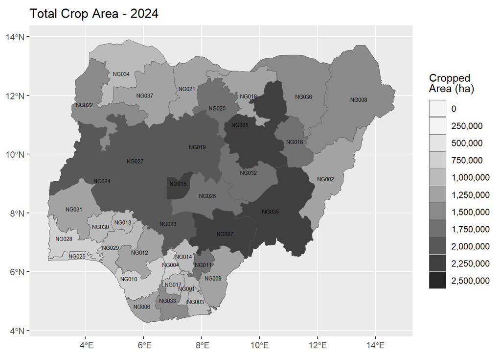

```r
ggplot(vect_total_cropped_2024) +
  geom_spatvector(aes(fill = Area_Ha_2024)) +
  geom_spatvector_text(aes(label = adm1_pcode), size = 2) +
  scale_fill_stepsn(
      n.breaks = 10,
      limits = c(0, 2500000),
      colours = hcl.colors(palette = "Grays", 10, rev = T),
      guide = "legend",  na.value = "pink", labels = scales::comma
    ) +
  labs(
    title = "Total Crop Area - 2024",
    fill = "Cropped<br>Area (ha)") +
  theme(
    plot.title = element_markdown(),
    legend.title = element_markdown(),
    axis.title = element_blank()
  )
```

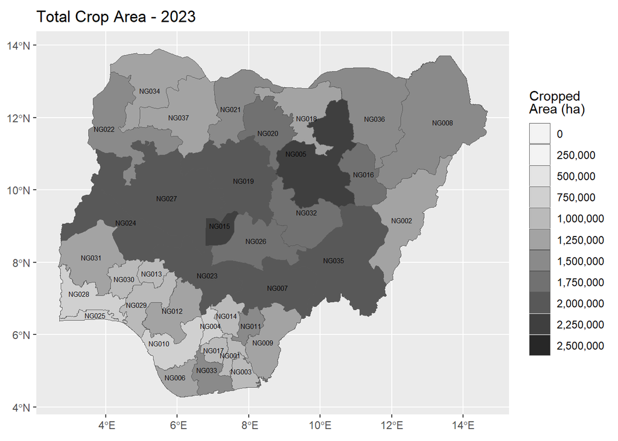

```r
ggplot(vect_total_cropped_2024) +
  geom_spatvector(aes(fill = Area_Ha_2023)) +
  geom_spatvector_text(aes(label = adm1_pcode), size = 2) +
  scale_fill_stepsn(
      n.breaks = 10,
      limits = c(0, 2500000),
      colours = hcl.colors(palette = "Grays", 10, rev = T),
      guide = "legend",  na.value = "pink", labels = scales::comma
    ) +
  labs(
    title = "Total Crop Area - 2023",
    fill = "Cropped<br>Area (ha)") +
  theme(
    plot.title = element_markdown(),
    legend.title = element_markdown(),
    axis.title = element_blank()
  )
```

### NASS crop database

```r
df_nass_total_cropped <- bind_cols(
  select(df_cashew_2022, adm1_ref_name, cashew_2022),
  select(df_cassava_2022, cassava_2022),
  select(df_chilli_2022, chilli_2022),
  select(df_cocoa_2022, cocoa_2022),
  select(df_cocoyam_2022, cocoyam_2022),
  select(df_cowpea_2022, cowpea_2022),
  select(df_gnut_2022, gnut_2022),
  select(df_maize_2022, maize_2022),
  select(df_millet_2022, millet_2022),
  select(df_opalm_2022, opalm_2022),
  select(df_okro_2022, okro_2022),
  select(df_onion_2022, onion_2022),
  select(df_plantain_banana_2022, plantain_banana_2022),
  select(df_rice_2022, rice_2022),
  select(df_sesame_2022, sesame_2022),
  select(df_sorghum_2022, sorghum_2022),
  select(df_soybean_2022, soybean_2022),
  select(df_spot_2022, spot_2022),
  select(df_tomato_2022, tomato_2022),
  select(df_yam_2022, yam_2022)
)

df_nass_total_cropped <- df_nass_total_cropped |>
  rowwise() |>
  mutate(sum_area = sum(cashew_2022, cassava_2022, chilli_2022, cocoa_2022, cocoyam_2022, cowpea_2022, gnut_2022, maize_2022, millet_2022, opalm_2022, okro_2022, onion_2022, plantain_banana_2022, rice_2022, sesame_2022, sorghum_2022, soybean_2022, spot_2022, tomato_2022, yam_2022, na.rm=TRUE))

vect_nass_total_cropped <- dplyr::left_join(vect_state_geo, df_nass_total_cropped, by = "adm1_ref_name")
```

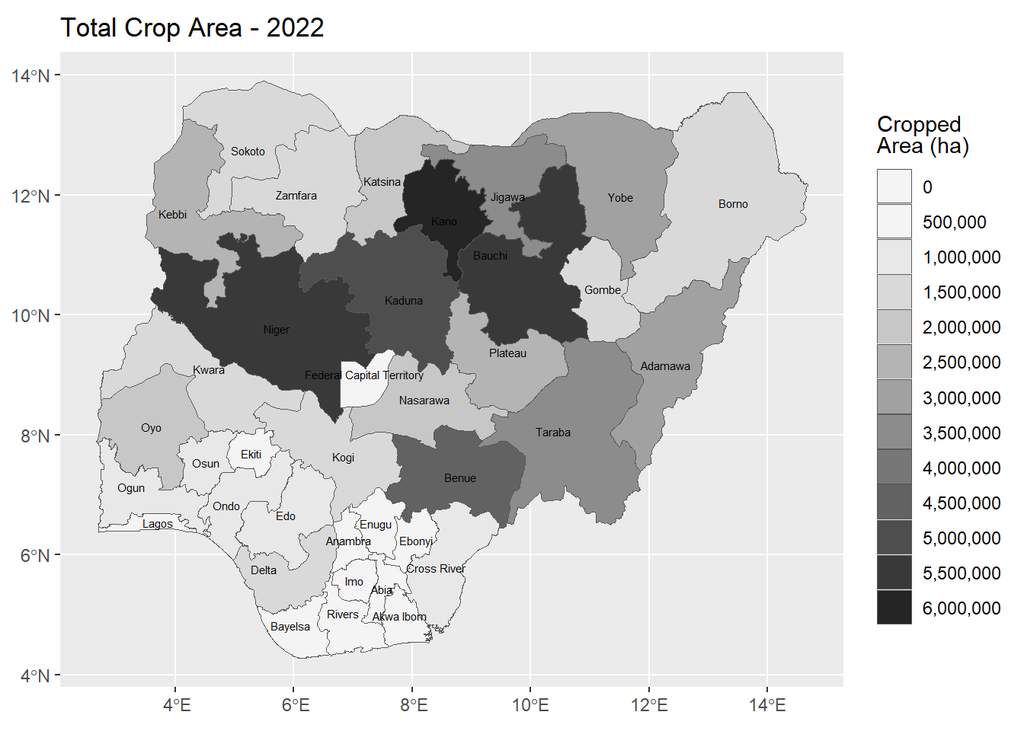

```r
ggplot(vect_nass_total_cropped) +
  geom_spatvector(aes(fill = sum_area)) +
  geom_spatvector_text(aes(label = adm1_name), size = 2) +
  scale_fill_stepsn(
      n.breaks = 10,
      limits = c(0, 6000000),
      colours = hcl.colors(palette = "Grays", 10, rev = T),
      guide = "legend",  na.value = "pink", labels = scales::comma
    ) +
  labs(
    title = "Total Crop Area - 2022",
    fill = "Cropped<br>Area (ha)") +
  theme(
    plot.title = element_markdown(),
    legend.title = element_markdown(),
    axis.title = element_blank()
  )
```

### HarvestStat

```r
vect_total_cropped_2023 <- dplyr::left_join(vect_state_geo, dplyr::filter(df_hstat, harvest_year == "2023", indicator == "area"), by = c("adm1_name" = "admin_1"))

vect_total_cropped_2023 <- vect_total_cropped_2023 |>
  dplyr::group_by(adm1_name) |>
  dplyr::summarise(sum_area = sum(value))
```

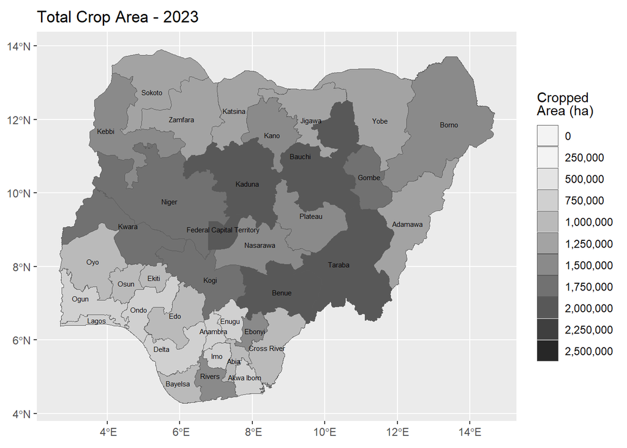

```r
ggplot(vect_total_cropped_2023) +
  geom_spatvector(aes(fill = sum_area)) +
  geom_spatvector_text(aes(label = adm1_name), size = 2) +
  scale_fill_stepsn(
      n.breaks = 10,
      limits = c(0, 2500000),
      colours = hcl.colors(palette = "Grays", 10, rev = T),
      guide = "legend",  na.value = "pink", labels = scales::comma
    ) +
  labs(
    title = "Total Crop Area - 2023",
    fill = "Cropped<br>Area (ha)") +
  theme(
    plot.title = element_markdown(),
    legend.title = element_markdown(),
    axis.title = element_blank()
  )
```

### MapSpam 2020

The MapSpam 2020 dataset does not contain codes for the states - only names. Therefore we need to join the two data frames using the name of the state - and checking that all states have data.

```r
vect_spam_total <- dplyr::left_join(vect_state_geo, df_spam_total, by = c("adm1_name" = "ADM1_NAME"))
```

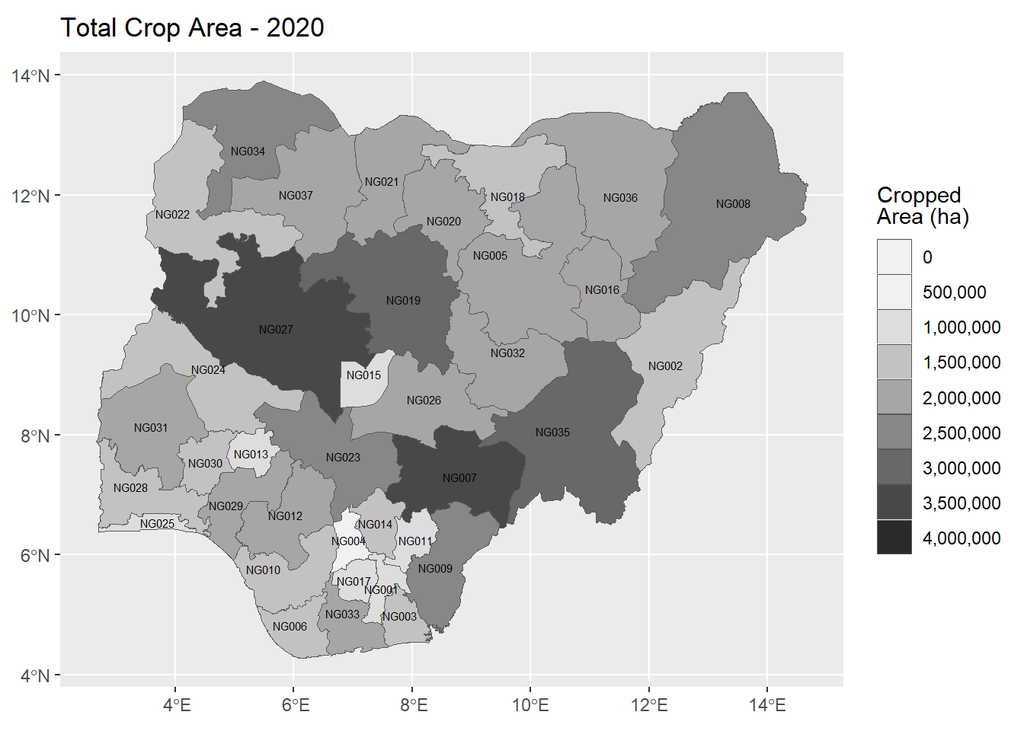

```r
ggplot(vect_spam_total) +
  geom_spatvector(aes(fill = total)) +
  geom_spatvector_text(aes(label = adm1_pcode), size = 2) +
  scale_fill_stepsn(
      n.breaks = 10,
      limits = c(0, 4000000),
      colours = hcl.colors(palette = "Grays", 10, rev = T),
      guide = "legend",  na.value = "pink", labels = scales::comma
    ) +
  labs(
    title = "Total Crop Area - 2020",
    fill = "Cropped<br>Area (ha)") +
  theme(
    plot.title = element_markdown(),
    legend.title = element_markdown(),
    axis.title = element_blank()
  )
```

### WorldCover 30

The WorldCover dataset has a spatial resolution of 10m, and includes a landcover class for cropland (Zanaga et al. 2022). The original raster needs to be reclassified as 1 for cropland and 0 for all other classes. Zonal statistics are then computed for each state - giving a pixel count. This value needs to be divided by 100 to give a value in hectares.

```r
# run once then save and load the results in subsequent runs
# rast_wc_1 <- rast(
# "E:/SpatialDataExternal/WorldCover_v200/terrascope_download_20241127_121517/WORLDCOVER/ESA_WORLDCOVER_10M_2021_V200/Worldcover_v_200_Nigeria-0000000000-0000131072.tif")
#
# rast_wc_2 <- rast(
# "E:/SpatialDataExternal/WorldCover_v200/terrascope_download_20241127_121517/WORLDCOVER/ESA_WORLDCOVER_10M_2021_V200/Worldcover_v_200_Nigeria-0000065536-0000131072.tif")
#
# rast_wc_3 <- rast(
# "E:/SpatialDataExternal/WorldCover_v200/terrascope_download_20241127_121517/WORLDCOVER/ESA_WORLDCOVER_10M_2021_V200/Worldcover_v_200_Nigeria-0000000000-0000000000.tif")
#
# rast_wc_4 <- rast(
# "E:/SpatialDataExternal/WorldCover_v200/terrascope_download_20241127_121517/WORLDCOVER/ESA_WORLDCOVER_10M_2021_V200/Worldcover_v_200_Nigeria-0000065536-0000065536.tif")
#
# rast_wc_5 <- rast(
# "E:/SpatialDataExternal/WorldCover_v200/terrascope_download_20241127_121517/WORLDCOVER/ESA_WORLDCOVER_10M_2021_V200/Worldcover_v_200_Nigeria-0000065536-0000000000.tif")
#
# rast_wc_6 <- rast(
# "E:/SpatialDataExternal/WorldCover_v200/terrascope_download_20241127_121517/WORLDCOVER/ESA_WORLDCOVER_10M_2021_V200/Worldcover_v_200_Nigeria-0000000000-0000065536.tif")
#
# rast_wc_nigeria <- mosaic(rast_wc_1, rast_wc_2, rast_wc_3, rast_wc_4, rast_wc_5, rast_wc_6)
# writeRaster(rast_wc_nigeria,"E:/SpatialDataExternal/WorldCover_v200/terrascope_download_20241127_121517/WORLDCOVER/ESA_WORLDCOVER_10M_2021_V200/Worldcover_v_200_Nigeria-mosaic.tif")
#
# rast_wc_nigeria <- rast(
# "E:/SpatialDataExternal/WorldCover_v200/terrascope_download_20241127_121517/WORLDCOVER/ESA_WORLDCOVER_10M_2021_V200/Worldcover_v_200_Nigeria-mosaic.tif")
#
# m_wc <- matrix(c(40, 1), nrow = 1, ncol = 2)
#
# rast_wc_nigeria_crop <- classify(rast_wc_nigeria, m_wc, others = 0)
#
# writeRaster(rast_wc_nigeria_crop,"E:/SpatialDataExternal/WorldCover_v200/terrascope_download_20241127_121517/WORLDCOVER/ESA_WORLDCOVER_10M_2021_V200/Worldcover_v_200_Nigeria-mosaic-crop.tif")
#
# rast_wc_nigeria_crop <- rast(
# "E:/SpatialDataExternal/WorldCover_v200/terrascope_download_20241127_121517/WORLDCOVER/ESA_WORLDCOVER_10M_2021_V200/Worldcover_v_200_Nigeria-mosaic-crop.tif")
#
# vect_wc_nigeria_crop <- zonal(rast_wc_nigeria_crop, vect_state_geo, fun="sum", exact = TRUE, weights = TRUE, as.polygons = TRUE, na.rm = TRUE)
### DIDN'T FINISH TRY IN QGIS ###
#
#
# writeVector(vect_wc_nigeria_crop, "E:/SpatialDataExternal/WorldCover_v200/terrascope_download_20241127_121517/WORLDCOVER/ESA_WORLDCOVER_10M_2021_V200/Worldcover_v_200_Nigeria-zonal-crop.geojson", overwrite=TRUE)

vect_wc_nigeria_crop<- vect(
"E:/SpatialDataExternal/WorldCover_v200/terrascope_download_20241127_121517/WORLDCOVER/ESA_WORLDCOVER_10M_2021_V200/Worldcover_v_200_Nigeria-zonal-crop.geojson")

vect_wc_nigeria_crop$Area_Ha_2021 <- (vect_wc_nigeria_crop$`_sum` / 100)
vect_wc_nigeria_crop$LandArea_Ha_2021 <- (vect_wc_nigeria_crop$`_count` / 100)
vect_wc_nigeria_crop$crop_pc_2021 <- ((vect_wc_nigeria_crop$Area_Ha_2021 / vect_wc_nigeria_crop$LandArea_Ha_2021) * 100)

df_wc_nigeria_crop <- as.data.frame(vect_wc_nigeria_crop)
df_wc_nigeria_crop['NAME_1'][df_wc_nigeria_crop['NAME_1'] == 'Nassarawa'] <- 'Nasarawa'
```

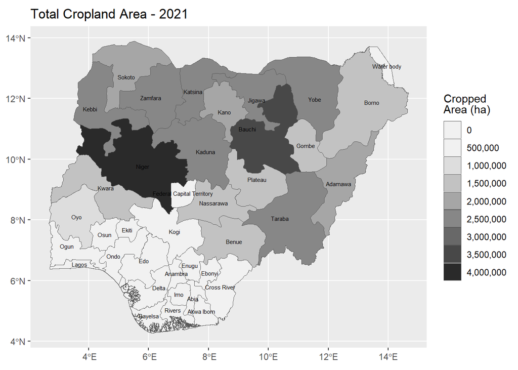

```r
ggplot(vect_wc_nigeria_crop) +
  geom_spatvector(aes(fill = Area_Ha_2021)) +
  geom_spatvector_text(aes(label = NAME_1), size = 2) +
  scale_fill_stepsn(
      n.breaks = 10,
      limits = c(0, 4000000),
      colours = hcl.colors(palette = "Grays", 10, rev = T),
      guide = "legend",  na.value = "pink", labels = scales::comma
    ) +
  labs(
    title = "Total Cropland Area - 2021",
    fill = "Cropped<br>Area (ha)") +
  theme(
    plot.title = element_markdown(),
    legend.title = element_markdown(),
    axis.title = element_blank()
  )
```

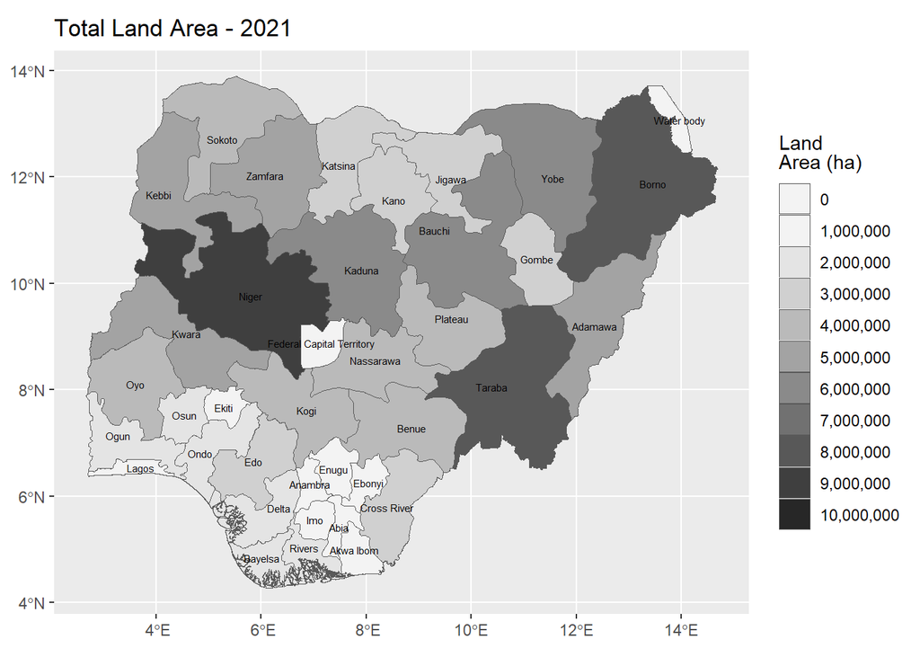

```r
ggplot(vect_wc_nigeria_crop) +
  geom_spatvector(aes(fill = LandArea_Ha_2021)) +
  geom_spatvector_text(aes(label = NAME_1), size = 2) +
  scale_fill_stepsn(
      n.breaks = 10,
      limits = c(0, 10000000),
      colours = hcl.colors(palette = "Grays", 10, rev = T),
      guide = "legend",  na.value = "pink", labels = scales::comma
    ) +
  labs(
    title = "Total Land Area - 2021",
    fill = "Land<br>Area (ha)") +
  theme(
    plot.title = element_markdown(),
    legend.title = element_markdown(),
    axis.title = element_blank()
  )
```

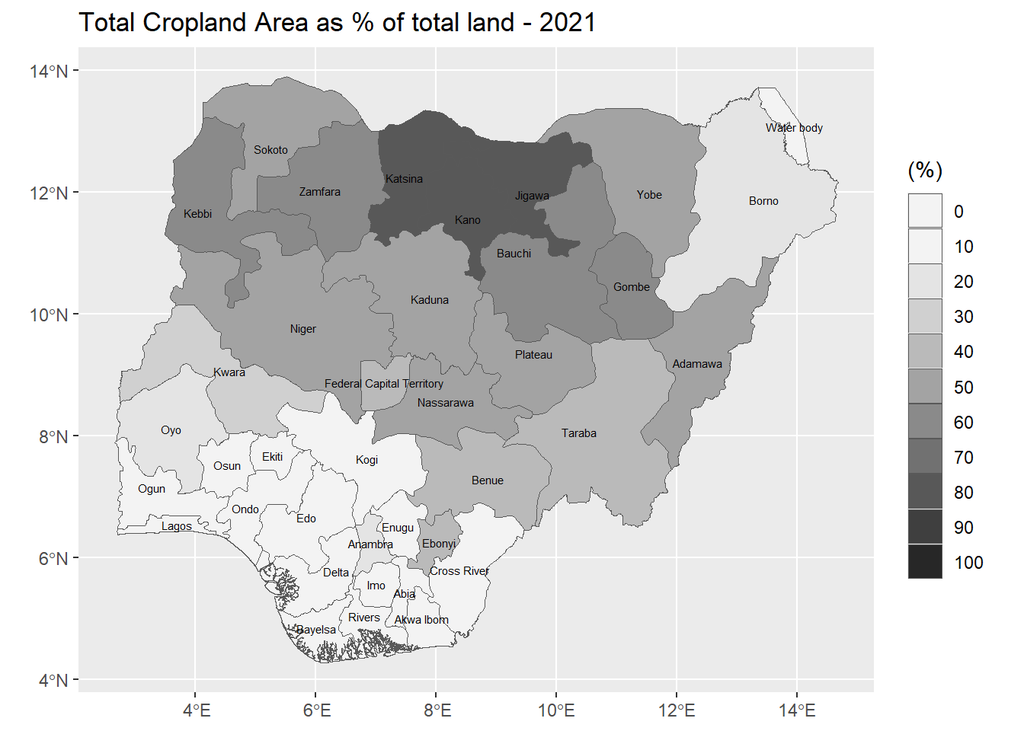

```r
ggplot(vect_wc_nigeria_crop) +
  geom_spatvector(aes(fill = crop_pc_2021)) +
  geom_spatvector_text(aes(label = NAME_1), size = 2) +
  scale_fill_stepsn(
      n.breaks = 10,
      limits = c(0, 100),
      colours = hcl.colors(palette = "Grays", 10, rev = T),
      guide = "legend",  na.value = "pink", labels = scales::comma
    ) +
  labs(
    title = "Total Cropland Area as % of total land - 2021",
    fill = "(%)") +
  theme(
    plot.title = element_markdown(),
    legend.title = element_markdown(),
    axis.title = element_blank()
  )
```

### Compare sources for total crop area

The table below displays all four sources together. The data are initially sorted according to the NAERLS data source, and by default the table shows the top 15 states - but you can change the number displayed. You can also change which column to sort by clicking on the arrows, and search for a specific state.

```r
df_total_comb <- dplyr::left_join(
  dplyr::select(
    df_total_cropped_2024,
    adm1_pcode,
    adm1_ref_name,
    Area_Ha_2024,
    Area_Ha_2023
  ),
  dplyr::select(df_wc_nigeria_crop, NAME_1, Area_Ha_2021),
  by = c('adm1_ref_name' = "NAME_1")
) |>
  dplyr::left_join(
    dplyr::select(df_nass_total_cropped, adm1_ref_name, sum_area),
    by = 'adm1_ref_name'
  ) |>
  dplyr::left_join(df_spam_total, by = c('adm1_ref_name' = 'ADM1_NAME'))


df_total_comb_rename <- df_total_comb |> dplyr::rename(NAERLS_2024 = Area_Ha_2024, NAERLS_2023 = Area_Ha_2023, NASS_2022 = sum_area, WC_2021 = Area_Ha_2021, MapSpam_2020 = total)

df_total_comb_rename_round <- df_total_comb_rename

df_total_comb_rename_round$NAERLS_2024 <- round(df_total_comb_rename$NAERLS_2024, digits = 0)
df_total_comb_rename_round$NAERLS_2023 <- round(df_total_comb_rename$NAERLS_2023, digits = 0)
df_total_comb_rename_round$NASS_2022 <- round(df_total_comb_rename$NASS_2022, digits = 0)
df_total_comb_rename_round$WC_2021 <- round(df_total_comb_rename$WC_2021, digits = 0)
df_total_comb_rename_round$MapSpam_2020 <- round(df_total_comb_rename$MapSpam_2020, digits = 0)


df_total_comb_rename_round |>
  base::sort_by(df_total_comb_rename_round$NAERLS_2024, decreasing = T) |>
  DT::datatable(
    rownames = F,
    filter = "bottom",
    selection = list(mode = "none"),
    editable = FALSE,
    options = list(
      digits = 0,
      scrollX = TRUE,
      scrollCollapse = TRUE,
      autoWidth = TRUE,
      fixedColumns = list(leftColumns = 2),
      lengthMenu = c(15, 40),
      pageLength = 15
    )
  )
```

| adm1_pcode | adm1_ref_name | NAERLS_2024 | NAERLS_2023 | WC_2021 | NASS_2022 | MapSpam_2020 |
| --- | --- | --- | --- | --- | --- | --- |
| NG015 | Federal Capital Territory | 2087009 | 2053090 | 270245 | 430921 | 803115 |
| NG005 | Bauchi | 2066775 | 2023860 | 3069466 | 5347629 | 1943873 |
| NG007 | Benue | 2012971 | 1978486 | 1178161 | 4123627 | 3001116 |
| NG035 | Taraba | 2012485 | 1972256 | 2170079 | 3308452 | 2974566 |
| NG024 | Kwara | 1867128 | 1838249 | 1024356 | 1293498 | 1459824 |
| NG019 | Kaduna | 1839108 | 1908106 | 2346141 | 4628943 | 2743059 |
| NG027 | Niger | 1818014 | 1790090 | 4199350 | 5149340 | 3250902 |
| NG023 | Kogi | 1809242 | 1781624 | 266088 | 1447265 | 2133446 |
| NG016 | Gombe | 1718791 | 1683139 | 1296146 | 1381099 | 1570286 |
| NG032 | Plateau | 1628648 | 1599107 | 1483731 | 2234042 | 1696304 |

[output cut: 27 more lines]

The comparison of crop areas among the sources shows some very large discrepancies among the sources. The most obvious difference is for the Federal Capital Territory. The NAERLS source gives a total crop area in excess of 2 million hectares, this in spite of the fact that the actual total area of the FCT (including urban areas, grassland, woodland etc.) is less than a million hectares.

Because NAERLS compiles its report using data sent in from individual State Agricultural Development Programmes (ADPs) and Ministries of Agriculture, errors usually trace back to a few specific systematic systemic issues:

- The Double-Counting Trap: If a single field in the FCT was used to grow multiple crops simultaneously (intercropping, such as mixing maize, sorghum, and cowpeas on the same plot), the data collectors likely recorded the full size of that field for each individual crop. When those crop areas were summed together vertically, it generated an inflated “total crop area” that exceeded the physical size of the land.
- Data Entry and Decimal Errors: A misplaced comma, extra zero, or basic typo during data aggregation can instantly turn a minor regional figure into a national peak.
- Flawed Projection Baselines: Lacking a real-time satellite mapping infrastructure, local agencies often rely on rough estimates or outdated population multipliers to guess cultivated areas, which completely breaks down when applied to a rapidly developing urban territory like FCT.

The NASS gives very large harvested areas for northern states like Kano Bauchi and Niger states. The data are derived from a household survey, so it is possible that there is double-counting where crops are grown together, or that plot areas are not calculated precisely.

The Worldcover map, in contrast, gives extremely low cropland cover estimates for the southern states. This may be because the classification algorithm doesn’t discriminate well between bushy semi-perennial crops - like cassava, or plantain - and shrub or tree cover, or because the cloud cover did not allow for sufficient satellite imagery.

## Banana & Plantain

### Banana/Plantain (NAERLS/FMAFS 2024)

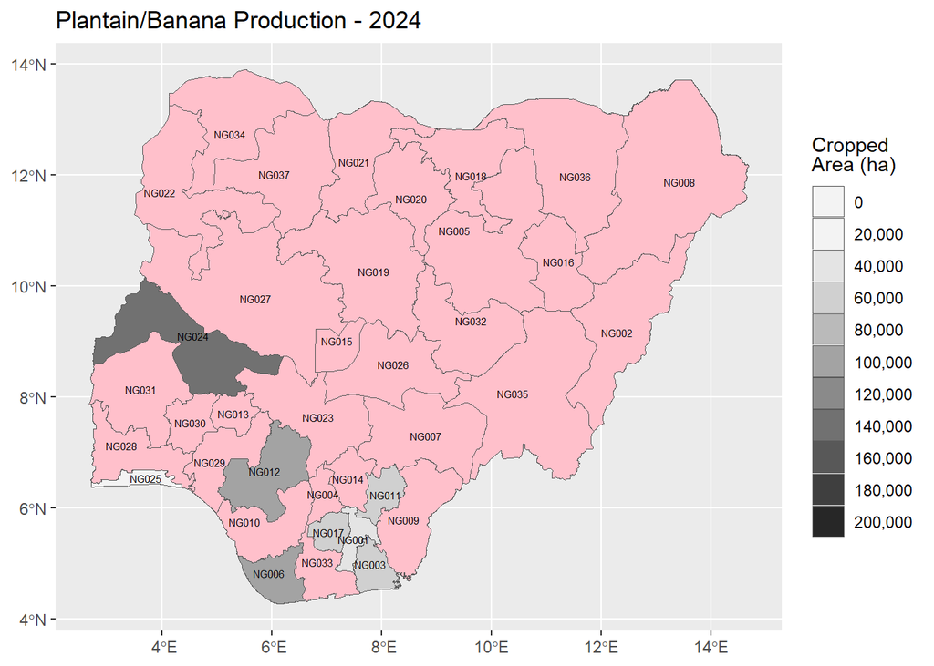

```r
ggplot(vect_plantain_banana_2024) +
  geom_spatvector(aes(fill = Area_Ha_2024)) +
  geom_spatvector_text(aes(label = adm1_pcode), size = 2) +
  scale_fill_stepsn(
      n.breaks = 10,
      limits = c(0, 200000),
      colours = hcl.colors(palette = "Grays", 10, rev = T),
      guide = "legend",  na.value = "pink", labels = scales::comma
    ) +
  labs(
    title = "Plantain/Banana Production - 2024",
    fill = "Cropped<br>Area (ha)") +
  theme(
    plot.title = element_markdown(),
    legend.title = element_markdown(),
    axis.title = element_blank()
  )
```

### Banana/Plantain (NASS 2022)

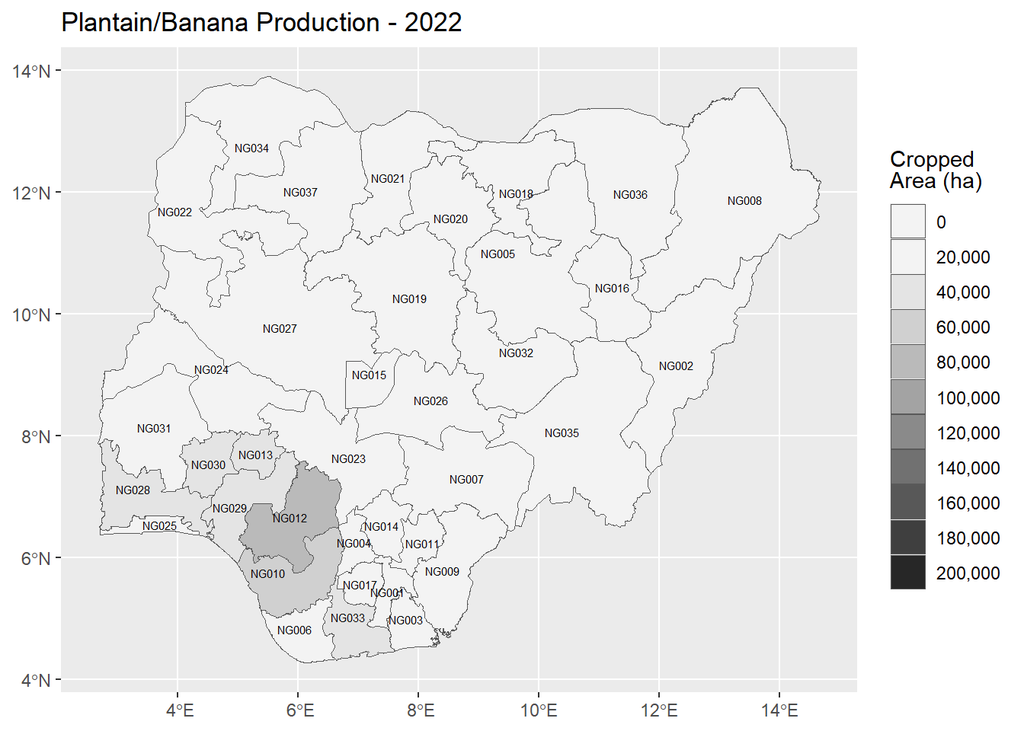

```r
ggplot(vect_plantain_banana_2022) +
  geom_spatvector(aes(fill = h_area_22_23_T)) +
  geom_spatvector_text(aes(label = adm1_pcode), size = 2) +
  scale_fill_stepsn(
      n.breaks = 10,
      limits = c(0, 200000),
      colours = hcl.colors(palette = "Grays", 10, rev = T),
      guide = "legend",  na.value = "pink", labels = scales::comma
    ) +
  labs(
    title = "Plantain/Banana Production - 2022",
    fill = "Cropped<br>Area (ha)") +
  theme(
    plot.title = element_markdown(),
    legend.title = element_markdown(),
    axis.title = element_blank()
  )
```

### Banana (HarvestStat 2021)

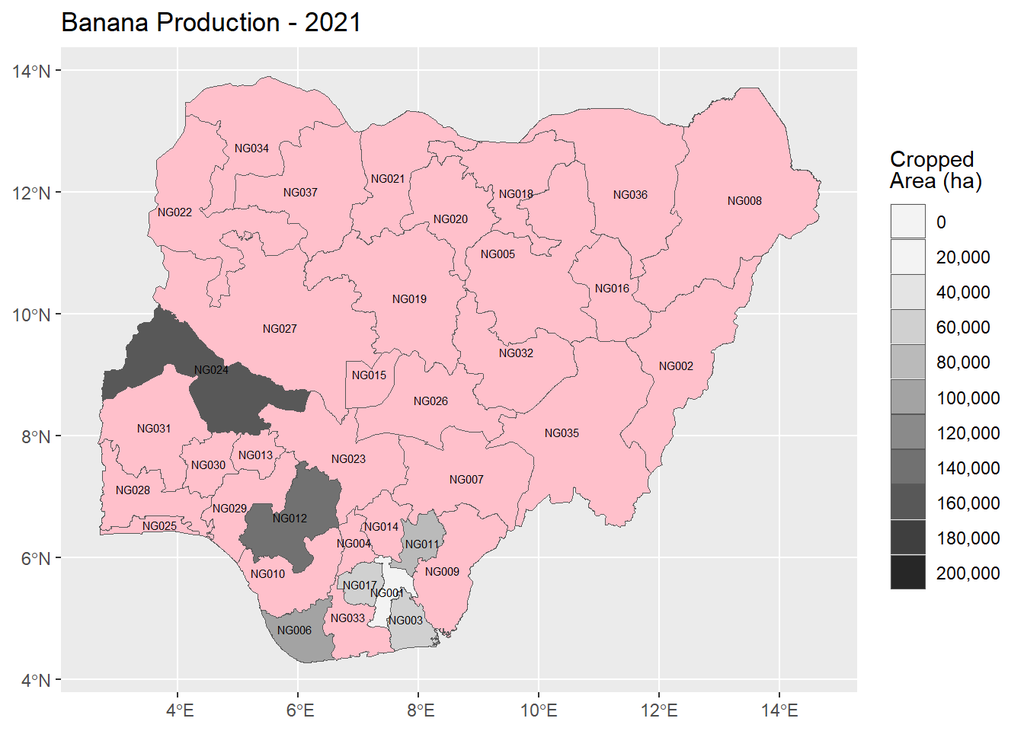

```r
ggplot(vect_banana_2021) +
  geom_spatvector(aes(fill = value)) +
  geom_spatvector_text(aes(label = adm1_pcode), size = 2) +
  scale_fill_stepsn(
      n.breaks = 10,
      limits = c(0, 200000),
      colours = hcl.colors(palette = "Grays", 10, rev = T),
      guide = "legend",  na.value = "pink", labels = scales::comma
    ) +
  labs(
    title = "Banana Production - 2021",
    fill = "Cropped<br>Area (ha)") +
  theme(
    plot.title = element_markdown(),
    legend.title = element_markdown(),
    axis.title = element_blank()
  )
```

### Banana & Plantain (MapSpam 2020)

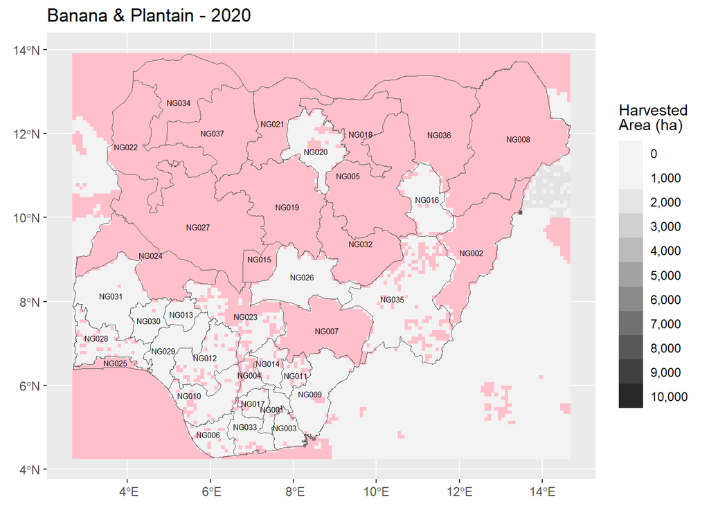

```r
ggplot() +
  geom_spatraster(data = rast_banp_spam_2020_nig) +
  geom_spatvector(data = vect_state_geo, fill = NA) +
  geom_spatvector_text(data = vect_state_geo, aes(label = adm1_pcode), size = 2) +
  scale_fill_stepsn(
      n.breaks = 10,
      limits = c(0, 10000),
      colours = hcl.colors(palette = "Grays", 10, rev = T),
      guide = "legend",  na.value = "pink", labels = scales::comma
    ) +
  labs(
    title = "Banana & Plantain - 2020",
    fill = "Harvested<br>Area (ha)") +
  theme(
    plot.title = element_markdown(),
    legend.title = element_markdown(),
    axis.title = element_blank()
  )
```

### Compare sources for Banana & Plantain

The table below displays all four sources together. The data are initially sorted according to the NAERLS data source, and by default the table shows the top 15 states - but you can change the number displayed. You can also change which column to sort by clicking on the arrows, and search for a specific state.

```r
df_banp_comb <- dplyr::left_join(
  dplyr::select(
    df_plantain_banana_2024,
    adm1_pcode,
    adm1_ref_name,
    plantain_banana_2024
  ),
  dplyr::select(df_banana_2021, adm1_pcode, banana_2021),
  by = 'adm1_pcode'
) |>
  dplyr::left_join(
    dplyr::select(df_plantain_banana_2022, plantain_banana_2022, adm1_ref_name),
    by = 'adm1_ref_name'
  ) |>
  dplyr::left_join(
    df_spam_banp_2,
    by = c('adm1_ref_name' = 'ADM1_NAME')
  )

df_banp_comb_rename <- df_banp_comb |> dplyr::rename(NAERLS_2024 = plantain_banana_2024, NASS_2022 = plantain_banana_2022, HarvestStat_2021 = banana_2021, MapSpam_2020 = sum_banp)

df_banp_comb_rename_round <- df_banp_comb_rename

df_banp_comb_rename_round$NAERLS_2024 <- round(df_banp_comb_rename$NAERLS_2024, digits = 0)
df_banp_comb_rename_round$NASS_2022 <- round(df_banp_comb_rename$NASS_2022, digits = 0)
df_banp_comb_rename_round$HarvestStat_2021 <- round(df_banp_comb_rename$HarvestStat_2021, digits = 0)
df_banp_comb_rename_round$MapSpam_2020 <- round(df_banp_comb_rename$MapSpam_2020, digits = 0)

df_banp_comb_rename_round |>
  base::sort_by(df_banp_comb_rename_round$NAERLS_2024, decreasing = T) |>
  DT::datatable(
    rownames = F,
    filter = "bottom",
    selection = list(mode = "none"),
    editable = FALSE,
    options = list(
      digits = 0,
      scrollX = TRUE,
      scrollCollapse = TRUE,
      autoWidth = TRUE,
      fixedColumns = list(leftColumns = 2),
      lengthMenu = c(15, 40),
      pageLength = 15
    )
  )
```

| adm1_pcode | adm1_ref_name | NAERLS_2024 | HarvestStat_2021 | NASS_2022 | MapSpam_2020 |
| --- | --- | --- | --- | --- | --- |
| NG024 | Kwara | 139712 | 142520 | 0 | 0 |
| NG012 | Edo | 98390 | 120870 | 64029 | 22636 |
| NG006 | Bayelsa | 89723 | 80540 | 18455 | 51917 |
| NG017 | Imo | 55485 | 42170 | 2464 | 18715 |
| NG003 | Akwa Ibom | 54646 | 54620 | 8849 | 28926 |
| NG011 | Ebonyi | 42333 | 65650 | 0 | 13729 |
| NG001 | Abia | 20518 | 18800 | 4748 | 12867 |
| NG025 | Lagos | 9622 |  | 3566 | 0 |
| NG002 | Adamawa |  |  | 0 | 0 |
| NG004 | Anambra |  |  | 5971 | 11658 |

[output cut: 27 more lines]

The NAERLS/FMAFS and HarvestStat data are more or less consistent, and it is likely that the HarvestStat data are the same as the NAERLS/FMAFS data from 2021. However, there are significant differences with the NASS data from 2022-23 and the MapSpam data for 2020. MapSpam has banana and plantain data for many more states than the other two sources. The patterns are different however: Kwara is the state with the largest area of banana and plantain in the NAERLS and HarvestStat sources, but has no harvested area in the MapSpam 2020 data.

The NASS data do not give values for individual states in the three northern geopolitical zones. The North Central zone has a harvested area of approximately 50,000ha of banana and plantain, but it is difficult to assign the area to states.

As a consequence, and despite the inconsistencies, the most suitable data to use are the NAERLS/FMAFS data from 2024 for Banana and Plantain due to the recency of the data.

## Cassava

### Cassava (NAERLS/FMAFS 2024)

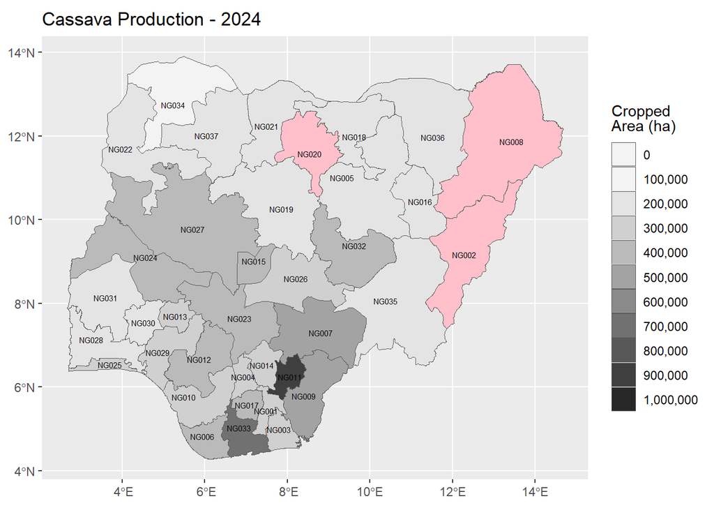

```r
ggplot(vect_cassava_2024) +
  geom_spatvector(aes(fill = Area_Ha_2024)) +
  geom_spatvector_text(aes(label = adm1_pcode), size = 2) +
  scale_fill_stepsn(
      n.breaks = 10,
      limits = c(0, 1000000),
      colours = hcl.colors(palette = "Grays", 10, rev = T),
      guide = "legend",  na.value = "pink", labels = scales::comma
    ) +
  labs(
    title = "Cassava Production - 2024",
    fill = "Cropped<br>Area (ha)") +
  theme(
    plot.title = element_markdown(),
    legend.title = element_markdown(),
    axis.title = element_blank()
  )
```

### Cassava (HarvestStat 2023)

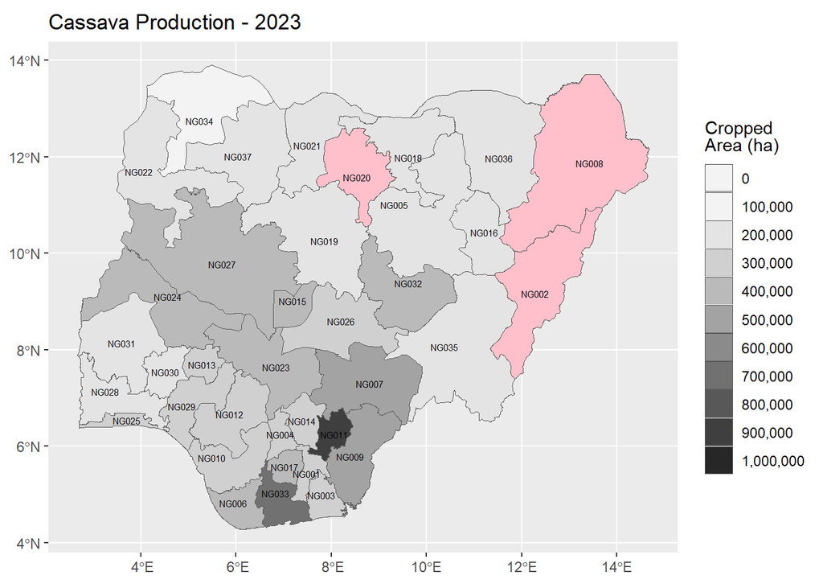

```r
ggplot(vect_cassava_2023) +
  geom_spatvector(aes(fill = value)) +
  geom_spatvector_text(aes(label = adm1_pcode), size = 2) +
  scale_fill_stepsn(
      n.breaks = 10,
      limits = c(0, 1000000),
      colours = hcl.colors(palette = "Grays", 10, rev = T),
      guide = "legend",  na.value = "pink", labels = scales::comma
    ) +
  labs(
    title = "Cassava Production - 2023",
    fill = "Cropped<br>Area (ha)") +
  theme(
    plot.title = element_markdown(),
    legend.title = element_markdown(),
    axis.title = element_blank()
  )
```

### Cassava (NASS 2022)

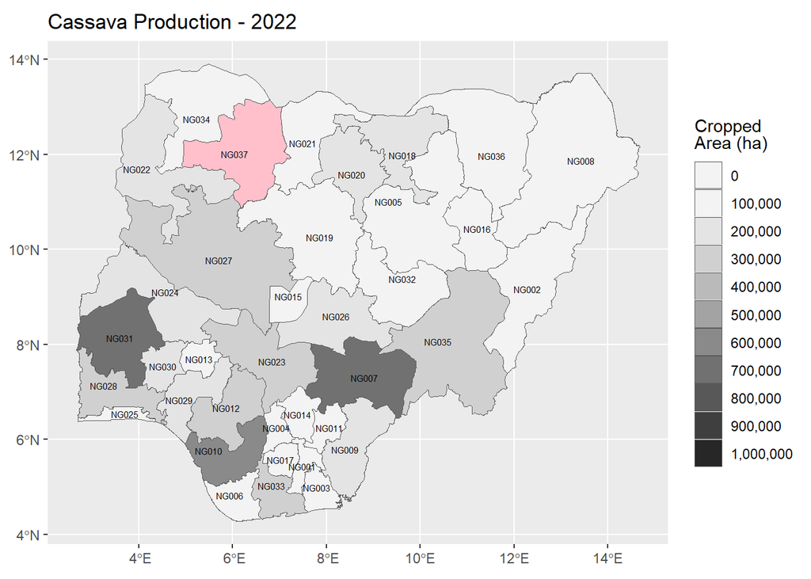

```r
ggplot(vect_cassava_2022) +
  geom_spatvector(aes(fill = h_area_22_23_T)) +
  geom_spatvector_text(aes(label = adm1_pcode), size = 2) +
  scale_fill_stepsn(
      n.breaks = 10,
      limits = c(0, 1000000),
      colours = hcl.colors(palette = "Grays", 10, rev = T),
      guide = "legend",  na.value = "pink", labels = scales::comma
    ) +
  labs(
    title = "Cassava Production - 2022",
    fill = "Cropped<br>Area (ha)") +
  theme(
    plot.title = element_markdown(),
    legend.title = element_markdown(),
    axis.title = element_blank()
  )
```

### Cassava (MapSpam 2020)

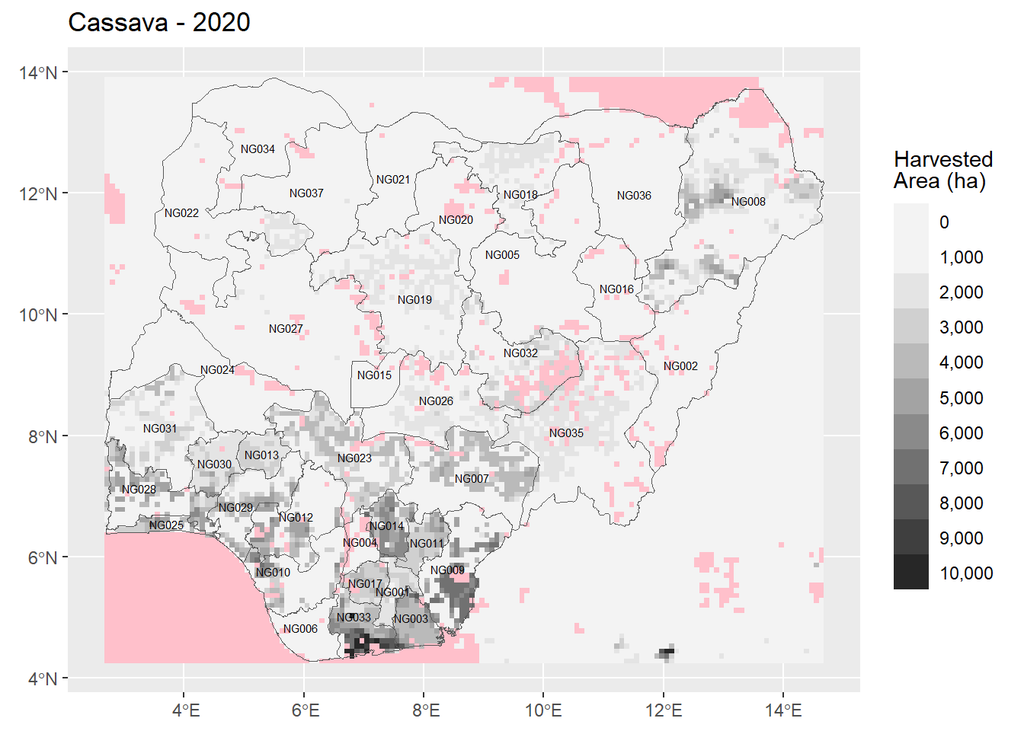

```r
ggplot() +
  geom_spatraster(data = rast_cassava_spam_2020_nig) +
  geom_spatvector(data = vect_state_geo, fill = NA) +
  geom_spatvector_text(data = vect_state_geo, aes(label = adm1_pcode), size = 2) +
  scale_fill_stepsn(
      n.breaks = 10,
      limits = c(0, 10000),
      colours = hcl.colors(palette = "Grays", 10, rev = T),
      guide = "legend",  na.value = "pink", labels = scales::comma
    ) +
  labs(
    title = "Cassava - 2020",
    fill = "Harvested<br>Area (ha)") +
  theme(
    plot.title = element_markdown(),
    legend.title = element_markdown(),
    axis.title = element_blank()
  )
```

### Compare sources

The table below displays all four sources together. The data are initially sorted according to the NAERLS data source, and by default the table shows the top 15 states - but you can change the number displayed. You can also change which column to sort by clicking on the arrows, and search for a specific state.

```r
df_cass_comb <- dplyr::left_join(
  dplyr::select(
    df_cassava_2024,
    adm1_pcode,
    adm1_ref_name,
    cassava_2024
  ),
  dplyr::select(df_cassava_2023, adm1_pcode, cassava_2023),
  by = 'adm1_pcode'
) |>
  dplyr::left_join(
    dplyr::select(df_cassava_2022, cassava_2022, adm1_ref_name),
    by = 'adm1_ref_name'
  ) |>
  dplyr::left_join(
    df_spam_cassava_2,
    by = c('adm1_ref_name' = 'ADM1_NAME')
  )


df_cass_comb_rename <- df_cass_comb |> dplyr::rename(NAERLS_2024 = cassava_2024, HarvestStat_2023 = cassava_2023, NASS_2022 = cassava_2022, MapSpam_2020 = sum_cassava)

df_cass_comb_rename_round <- df_cass_comb_rename

df_cass_comb_rename_round$NAERLS_2024 <- round(df_cass_comb_rename$NAERLS_2024, digits = 0)
df_cass_comb_rename_round$HarvestStat_2023 <- round(df_cass_comb_rename$HarvestStat_2023, digits = 0)
df_cass_comb_rename_round$NASS_2022 <- round(df_cass_comb_rename$NASS_2022, digits = 0)
df_cass_comb_rename_round$MapSpam_2020 <- round(df_cass_comb_rename$MapSpam_2020, digits = 0)

df_cass_comb_rename_round |>
  base::sort_by(df_cass_comb_rename_round$NAERLS_2024, decreasing = T) |>
  DT::datatable(
    rownames = F,
    filter = "bottom",
    selection = list(mode = "none"),
    editable = FALSE,
    options = list(
      digits = 0,
      scrollX = TRUE,
      scrollCollapse = TRUE,
      autoWidth = TRUE,
      fixedColumns = list(leftColumns = 2),
      lengthMenu = c(15, 40),
      pageLength = 15
    )
  )
```

| adm1_pcode | adm1_ref_name | NAERLS_2024 | HarvestStat_2023 | NASS_2022 | MapSpam_2020 |
| --- | --- | --- | --- | --- | --- |
| NG011 | Ebonyi | 824900 | 811111 | 53636 | 229655 |
| NG033 | Rivers | 619304 | 608952 | 285849 | 517329 |
| NG009 | Cross River | 421342 | 414299 | 151007 | 557796 |
| NG007 | Benue | 418613 | 411615 | 681996 | 532188 |
| NG024 | Kwara | 391039 | 384502 | 162291 | 58744 |
| NG023 | Kogi | 369302 | 363129 | 279060 | 551852 |
| NG006 | Bayelsa | 366505 | 360378 | 49473 | 48292 |
| NG015 | Federal Capital Territory | 356782 | 350818 | 44768 | 7540 |
| NG027 | Niger | 348462 | 345012 | 235814 | 283709 |
| NG017 | Imo | 320370 | 315015 | 70998 | 158987 |

[output cut: 27 more lines]

The HarvestStat appears to use the same data source as NAERLS, so these data sources are consistent. There are some notable differences with the NASS data from 2022-23 and the MapSpam data for 2020. The Federal Capital Territory has a very low harvested area in MapSpam compared with NAERLS 2024 data, and an intermediate harvested area in the NASS dataset. Similarly Bayelsa and Kwara have lower areas in MapSpam and NASS. Meanwhile in MapSpam Borno state has a very large cassava harvested area - bigger than any other state in fact. In the NAERLS source there are no data for Borno, Kano or Adamawa. The former two states are generally not considered large producers of Cassava, but Adamawa is considered a minor producing region so this omission is surprising.

The state with the largest harvested area in the NASS data is Benue, followed closely by Oyo. These are large agricultural states and the figures seem more probable than the large area given by NAERLS for Ebonyi, which has a smaller overall land area.

The NASS data is the most appropriate to use, given its provenance and despite the fact that it is two years older than the NAERLS data.

## Cowpea

### Cowpea (NAERLS/FMAFS 2024)

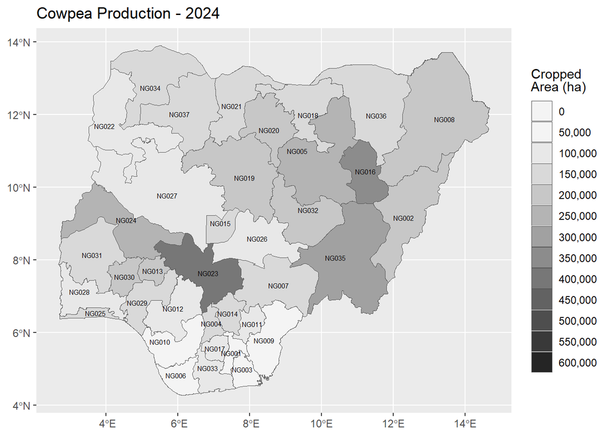

```r
ggplot(vect_cowpea_2024) +
  geom_spatvector(aes(fill = Area_Ha_2024)) +
  geom_spatvector_text(aes(label = adm1_pcode), size = 2) +
  scale_fill_stepsn(
      n.breaks = 10,
      limits = c(0, 600000),
      colours = hcl.colors(palette = "Grays", 10, rev = T),
      guide = "legend",  na.value = "pink", labels = scales::comma
    ) +
  labs(
    title = "Cowpea Production - 2024",
    fill = "Cropped<br>Area (ha)") +
  theme(
    plot.title = element_markdown(),
    legend.title = element_markdown(),
    axis.title = element_blank()
  )
```

### Cowpea (HarvestStat 2023)

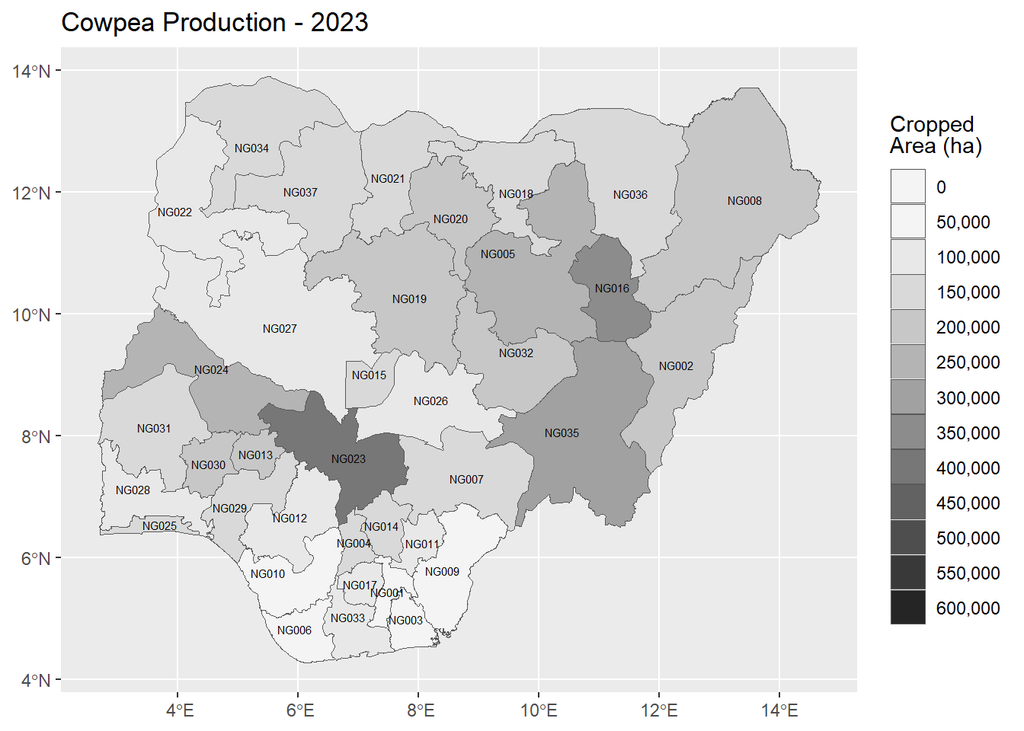

```r
ggplot(vect_cowpea_2023) +
  geom_spatvector(aes(fill = value)) +
  geom_spatvector_text(aes(label = adm1_pcode), size = 2) +
  scale_fill_stepsn(
      n.breaks = 10,
      limits = c(0, 600000),
      colours = hcl.colors(palette = "Grays", 10, rev = T),
      guide = "legend",  na.value = "pink", labels = scales::comma
    ) +
  labs(
    title = "Cowpea Production - 2023",
    fill = "Cropped<br>Area (ha)") +
  theme(
    plot.title = element_markdown(),
    legend.title = element_markdown(),
    axis.title = element_blank()
  )
```

### Cowpea (NASS 2022)

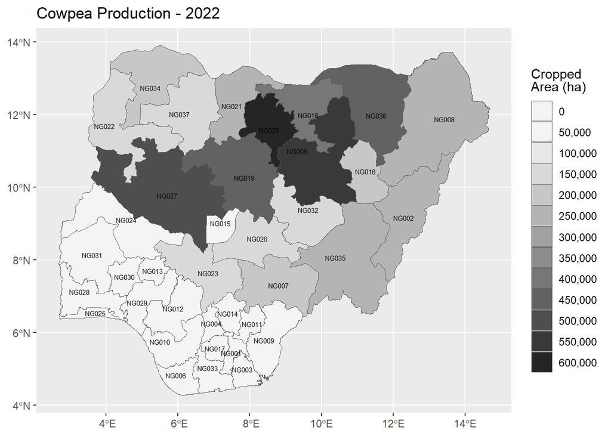

```r
ggplot(vect_cowpea_2022) +
  geom_spatvector(aes(fill = h_area_22_23_T)) +
  geom_spatvector_text(aes(label = adm1_pcode), size = 2) +
  scale_fill_stepsn(
      n.breaks = 10,
      limits = c(0, 600000),
      colours = hcl.colors(palette = "Grays", 10, rev = T),
      guide = "legend",  na.value = "pink", labels = scales::comma
    ) +
  labs(
    title = "Cowpea Production - 2022",
    fill = "Cropped<br>Area (ha)") +
  theme(
    plot.title = element_markdown(),
    legend.title = element_markdown(),
    axis.title = element_blank()
  )
```

### Cowpea (MapSpam 2020)

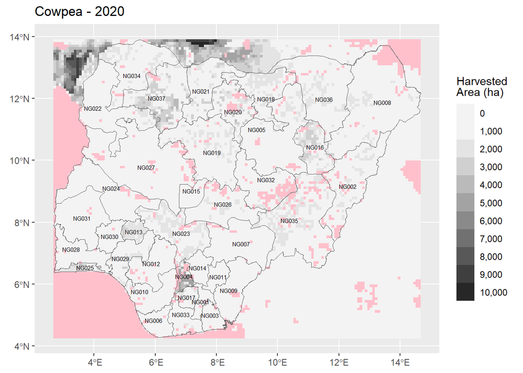

```r
ggplot() +
  geom_spatraster(data = rast_cowpea_spam_2020_nig) +
  geom_spatvector(data = vect_state_geo, fill = NA) +
  geom_spatvector_text(data = vect_state_geo, aes(label = adm1_pcode), size = 2) +
  scale_fill_stepsn(
      n.breaks = 10,
      limits = c(0, 10000),
      colours = hcl.colors(palette = "Grays", 10, rev = T),
      guide = "legend",  na.value = "pink", labels = scales::comma
    ) +
  labs(
    title = "Cowpea - 2020",
    fill = "Harvested<br>Area (ha)") +
  theme(
    plot.title = element_markdown(),
    legend.title = element_markdown(),
    axis.title = element_blank()
  )
```

### Compare sources

The table below displays all four sources together. The data are initially sorted according to the NAERLS data source, and by default the table shows the top 15 states - but you can change the number displayed. You can also change which column to sort by clicking on the arrows, and search for a specific state.

```r
df_cowp_comb <- dplyr::left_join(
  dplyr::select(
    df_cowpea_2024,
    adm1_pcode,
    adm1_ref_name,
    cowpea_2024
  ),
  dplyr::select(df_cowpea_2023, adm1_pcode, cowpea_2023),
  by = 'adm1_pcode'
) |>
  dplyr::left_join(
    dplyr::select(df_cowpea_2022, cowpea_2022, adm1_ref_name),
    by = 'adm1_ref_name'
  ) |>
  dplyr::left_join(
    df_spam_cowpea_2,
    by = c('adm1_ref_name' = 'ADM1_NAME')
  )


df_cowp_comb_rename <- df_cowp_comb |> dplyr::rename(NAERLS_2024 = cowpea_2024, HarvestStat_2023 = cowpea_2023, NASS_2022 = cowpea_2022, MapSpam_2020 = sum_cowpea)

df_cowp_comb_rename_round <- df_cowp_comb_rename

df_cowp_comb_rename_round$NAERLS_2024 <- round(df_cowp_comb_rename$NAERLS_2024, digits = 0)
df_cowp_comb_rename_round$HarvestStat_2023 <- round(df_cowp_comb_rename$HarvestStat_2023, digits = 0)
df_cass_comb_rename_round$NASS_2022 <- round(df_cowp_comb_rename$NASS_2022, digits = 0)
df_cowp_comb_rename_round$MapSpam_2020 <- round(df_cowp_comb_rename$MapSpam_2020, digits = 0)

df_cowp_comb_rename_round |>
  base::sort_by(df_cowp_comb_rename_round$NAERLS_2024, decreasing = T) |>
  DT::datatable(
    rownames = F,
    filter = "bottom",
    selection = list(mode = "none"),
    editable = FALSE,
    options = list(
      digits = 0,
      scrollX = TRUE,
      scrollCollapse = TRUE,
      autoWidth = TRUE,
      fixedColumns = list(leftColumns = 2),
      lengthMenu = c(15, 40),
      pageLength = 15
    )
  )
```

| adm1_pcode | adm1_ref_name | NAERLS_2024 | HarvestStat_2023 | NASS_2022 | MapSpam_2020 |
| --- | --- | --- | --- | --- | --- |
| NG023 | Kogi | 356541 | 353011 | 133455 | 232257 |
| NG016 | Gombe | 326036 | 322808 | 198084 | 216262 |
| NG035 | Taraba | 255999 | 253465 | 202711 | 291043 |
| NG024 | Kwara | 230184 | 227905 | 49848 | 102194 |
| NG005 | Bauchi | 214601 | 212477 | 518137 | 204819 |
| NG030 | Osun | 198015 | 196055 | 0 | 5544 |
| NG002 | Adamawa | 190911 | 189021 | 230855 | 142333 |
| NG020 | Kano | 187281 | 185795 | 550338 | 248669 |
| NG008 | Borno | 186797 | 197043 | 207899 | 222433 |
| NG032 | Plateau | 167593 | 165934 | 144690 | 111491 |

[output cut: 27 more lines]

There are some considerable differences between the NAERLS, NASS and MapSpam data. These are unlikely to be due to the 4 years difference between the sources. The state with the largest area of cowpea in the NAERLS source is Kogi, whereas for NASS it is Kano and for MapSpam it is Zamfara. All three states have agro-ecological conditions suitable for growing cowpea, but the figures for Zamfara seem excessive - almost double the area of cowpea in Taraba - the state with the second highest harvested area. NAERLS acknowledge that production in Zamfara had declined recently due to adverse weather conditions, pest infestations, and reduced input use.

Other notable differences are Osun (where NAERLS estimates almost 200 thousand and MapSpam just 5544 hectares), Niger state where NASS estimates almost half a million hectares whereas the NAERLS estimates are just 80,000, and Abia where MapSpam is extremely low.

The NASS data do not give values for individual states in the three southern geopolitical zones. The South west zone has a harvested area of approximately 55,000ha of cowpea, but it is difficult to assign the area to states. Nevertheless the harvested areas are very small compared to the northern zones.

Despite the lack of data for southern zones the NASS data better capture the cowpea growing areas and do not have obvious anomalies. However, the comparison shows that year-to-year variations will have an impact on how the crop area are used and interpreted.

## Maize

### Maize (NAERLS/FMAFS 2024)

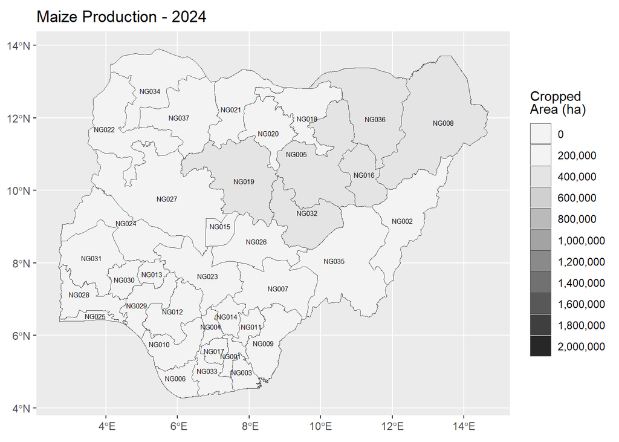

```r
ggplot(vect_maize_2024) +
  geom_spatvector(aes(fill = Area_Ha_2024)) +
  geom_spatvector_text(aes(label = adm1_pcode), size = 2) +
  scale_fill_stepsn(
      n.breaks = 10,
      limits = c(0, 2000000),
      colours = hcl.colors(palette = "Grays", 10, rev = T),
      guide = "legend",  na.value = "pink", labels = scales::comma
    ) +
  labs(
    title = "Maize Production - 2024",
    fill = "Cropped<br>Area (ha)") +
  theme(
    plot.title = element_markdown(),
    legend.title = element_markdown(),
    axis.title = element_blank()
  )
```

### Maize (HarvestStat 2023)

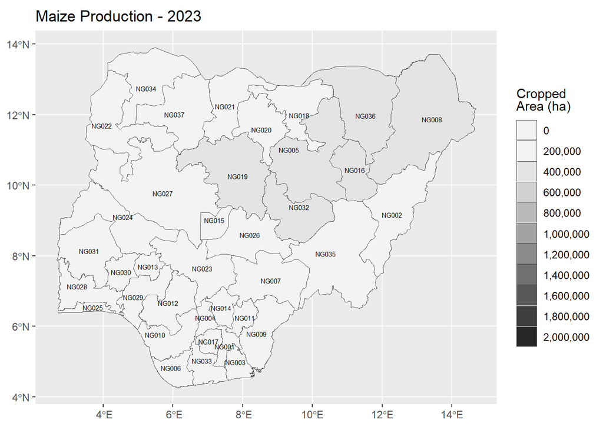

```r
ggplot(vect_maize_2023) +
  geom_spatvector(aes(fill = value)) +
  geom_spatvector_text(aes(label = adm1_pcode), size = 2) +
  scale_fill_stepsn(
      n.breaks = 10,
      limits = c(0, 2000000),
      colours = hcl.colors(palette = "Grays", 10, rev = T),
      guide = "legend",  na.value = "pink", labels = scales::comma
    ) +
  labs(
    title = "Maize Production - 2023",
    fill = "Cropped<br>Area (ha)") +
  theme(
    plot.title = element_markdown(),
    legend.title = element_markdown(),
    axis.title = element_blank()
  )
```

### Maize (NASS 2022)

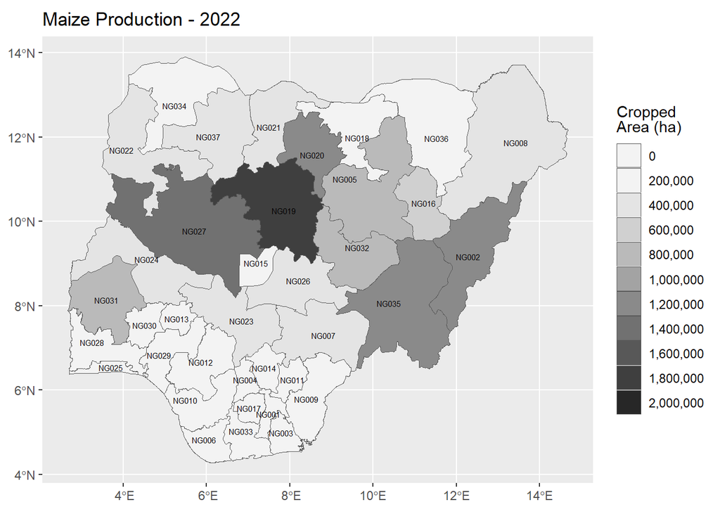

```r
ggplot(vect_maize_2022) +
  geom_spatvector(aes(fill = h_area_22_23_T)) +
  geom_spatvector_text(aes(label = adm1_pcode), size = 2) +
  scale_fill_stepsn(
      n.breaks = 10,
      limits = c(0, 2000000),
      colours = hcl.colors(palette = "Grays", 10, rev = T),
      guide = "legend",  na.value = "pink", labels = scales::comma
    ) +
  labs(
    title = "Maize Production - 2022",
    fill = "Cropped<br>Area (ha)") +
  theme(
    plot.title = element_markdown(),
    legend.title = element_markdown(),
    axis.title = element_blank()
  )
```

### Maize (MapSpam 2020)

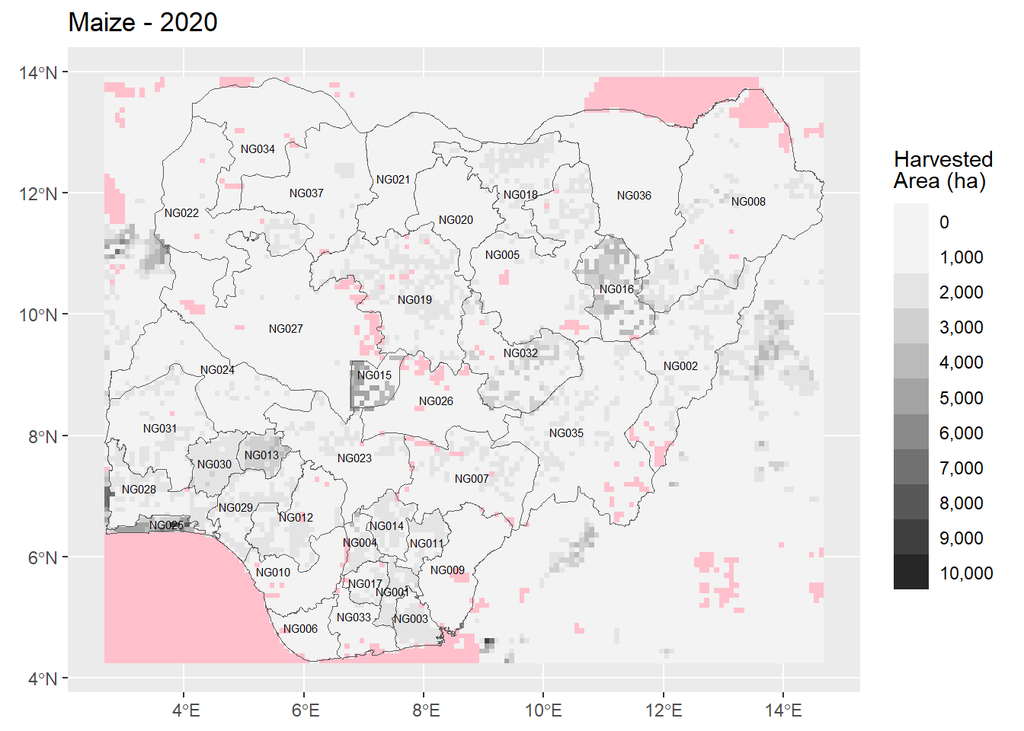

```r
ggplot() +
  geom_spatraster(data = rast_maize_spam_2020_nig) +
  geom_spatvector(data = vect_state_geo, fill = NA) +
  geom_spatvector_text(data = vect_state_geo, aes(label = adm1_pcode), size = 2) +
  scale_fill_stepsn(
      n.breaks = 10,
      limits = c(0, 10000),
      colours = hcl.colors(palette = "Grays", 10, rev = T),
      guide = "legend",  na.value = "pink", labels = scales::comma
    ) +
  labs(
    title = "Maize - 2020",
    fill = "Harvested<br>Area (ha)") +
  theme(
    plot.title = element_markdown(),
    legend.title = element_markdown(),
    axis.title = element_blank()
  )
```

### Compare sources for Maize

The table below displays all four sources together. The data are initially sorted according to the NAERLS data source, and by default the table shows the top 15 states - but you can change the number displayed. You can also change which column to sort by clicking on the arrows, and search for a specific state.

```r
df_maize_comb <- dplyr::left_join(
  dplyr::select(
    df_maize_2024,
    adm1_pcode,
    adm1_ref_name,
    maize_2024
  ),
  dplyr::select(df_maize_2023, adm1_pcode, maize_2023),
  by = 'adm1_pcode'
) |>
  dplyr::left_join(
    dplyr::select(df_maize_2022, maize_2022, adm1_ref_name),
    by = 'adm1_ref_name'
  ) |>
  dplyr::left_join(
    df_spam_maize_2,
    by = c('adm1_ref_name' = 'ADM1_NAME')
  )


df_maize_comb_rename <- df_maize_comb |> dplyr::rename(NAERLS_2024 = maize_2024, HarvestStat_2023 = maize_2023, NASS_2022 = maize_2022, MapSpam_2020 = sum_maize)

df_maize_comb_rename_round <- df_maize_comb_rename

df_maize_comb_rename_round$NAERLS_2024 <- round(df_maize_comb_rename$NAERLS_2024, digits = 0)
df_maize_comb_rename_round$HarvestStat_2023 <- round(df_maize_comb_rename$HarvestStat_2023, digits = 0)
df_maize_comb_rename_round$NASS_2022 <- round(df_maize_comb_rename$NASS_2022, digits = 0)
df_maize_comb_rename_round$MapSpam_2020 <- round(df_maize_comb_rename$MapSpam_2020, digits = 0)

df_maize_comb_rename_round |>
  base::sort_by(df_maize_comb_rename_round$NAERLS_2024, decreasing = T) |>
  DT::datatable(
    rownames = F,
    filter = "bottom",
    selection = list(mode = "none"),
    editable = FALSE,
    options = list(
      digits = 0,
      scrollX = TRUE,
      scrollCollapse = TRUE,
      autoWidth = TRUE,
      fixedColumns = list(leftColumns = 2),
      lengthMenu = c(15, 40),
      pageLength = 15
    )
  )
```

| adm1_pcode | adm1_ref_name | NAERLS_2024 | HarvestStat_2023 | NASS_2022 | MapSpam_2020 |
| --- | --- | --- | --- | --- | --- |
| NG005 | Bauchi | 354144 | 348910 | 744968 | 297513 |
| NG016 | Gombe | 316443 | 311767 | 458821 | 368306 |
| NG036 | Yobe | 313119 | 312494 | 108041 | 145732 |
| NG019 | Kaduna | 275750 | 308101 | 1717833 | 358204 |
| NG008 | Borno | 260121 | 259861 | 316850 | 367137 |
| NG032 | Plateau | 249708 | 246017 | 757475 | 260887 |
| NG027 | Niger | 177791 | 175163 | 1258964 | 281789 |
| NG002 | Adamawa | 168622 | 166130 | 1034456 | 189287 |
| NG015 | Federal Capital Territory | 158245 | 155906 | 123738 | 196613 |
| NG018 | Jigawa | 149473 | 147264 | 77487 | 177332 |

[output cut: 27 more lines]

The comparison of maize crop area between MapSpam and NAERLS show more consistency than other crops - at least for states like Gombe, Bauchi, Kaduna and Borno. A state that has a large difference is Yobe. In the 2020 MapSpam data the harvested area is less than 150,000 hectares, whereas in the NAERLS and HarvestStat data for 2024 and 2023 respectively the area is more than double. The opposite situation is encountered for Borno, although declines in production were acknowledged in the NAERLS 2024 report.

There are very big differences between NASS and the other two sources. The overall harvest area for maize is large, with five states estimated to have harvested over a million hectares each. Nevertheless, the pattern of production is more consistent with the agro-ecological zones of Nigeria. For this reason the NASS data are the best source for maize.

## Rice

### Rice (NAERLS/FMAFS 2024)

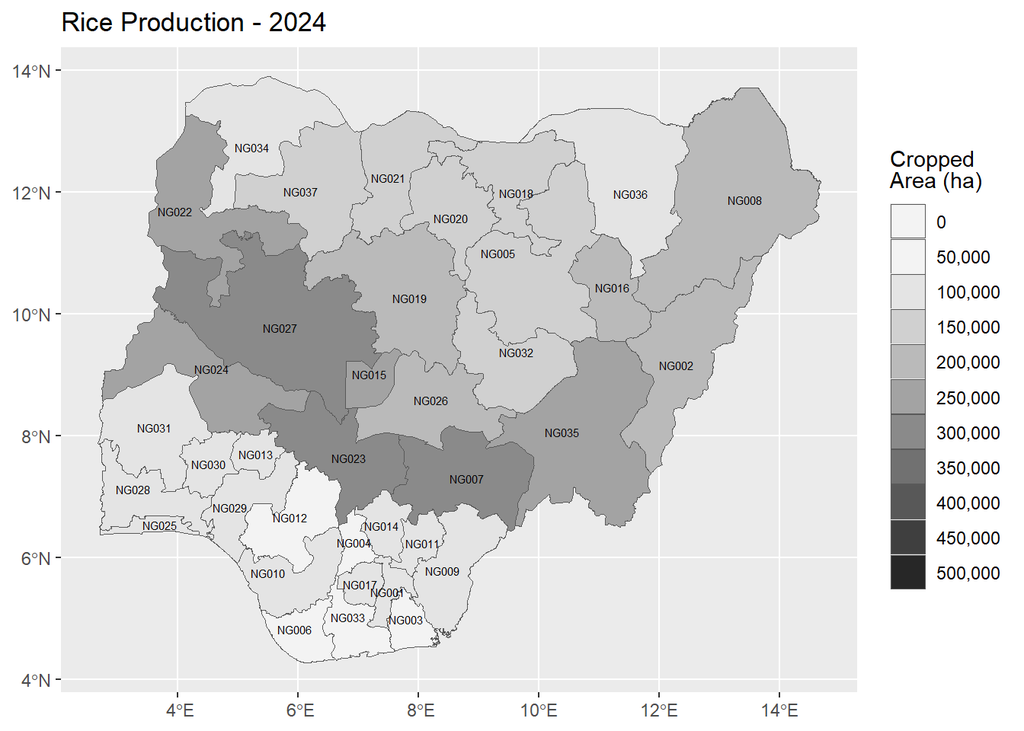

```r
ggplot(vect_rice_2024) +
  geom_spatvector(aes(fill = Area_Ha_2024)) +
  geom_spatvector_text(aes(label = adm1_pcode), size = 2) +
  scale_fill_stepsn(
      n.breaks = 10,
      limits = c(0, 500000),
      colours = hcl.colors(palette = "Grays", 10, rev = T),
      guide = "legend",  na.value = "pink", labels = scales::comma
    ) +
  labs(
    title = "Rice Production - 2024",
    fill = "Cropped<br>Area (ha)") +
  theme(
    plot.title = element_markdown(),
    legend.title = element_markdown(),
    axis.title = element_blank()
  )
```

### Rice (HarvestStat 2023)

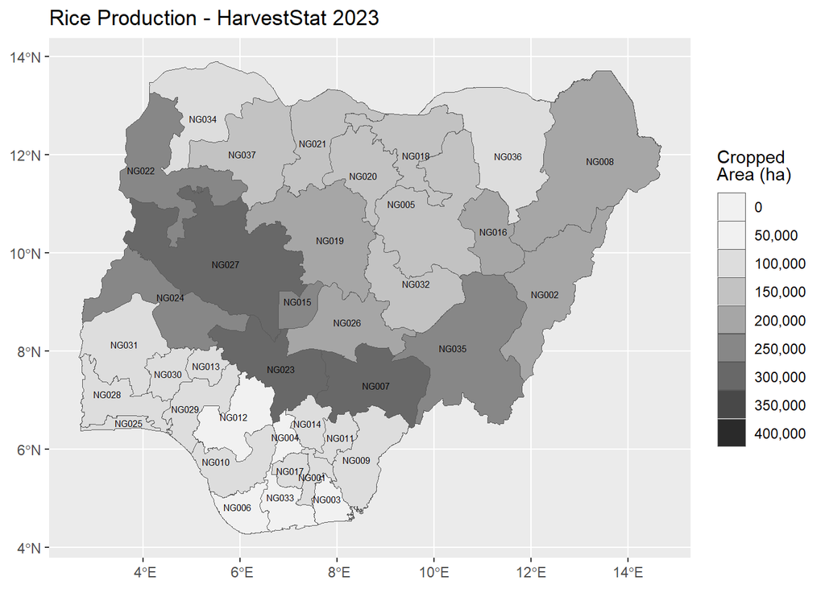

```r
ggplot(vect_rice_2023) +
  geom_spatvector(aes(fill = value)) +
  geom_spatvector_text(aes(label = adm1_pcode), size = 2) +
  scale_fill_stepsn(
      n.breaks = 10,
      limits = c(0, 400000),
      colours = hcl.colors(palette = "Grays", 10, rev = T),
      guide = "legend",  na.value = "pink", labels = scales::comma
    ) +
  labs(
    title = "Rice Production - HarvestStat 2023",
    fill = "Cropped<br>Area (ha)") +
  theme(
    plot.title = element_markdown(),
    legend.title = element_markdown(),
    axis.title = element_blank()
  )
```

### Rice (NASS 2022)

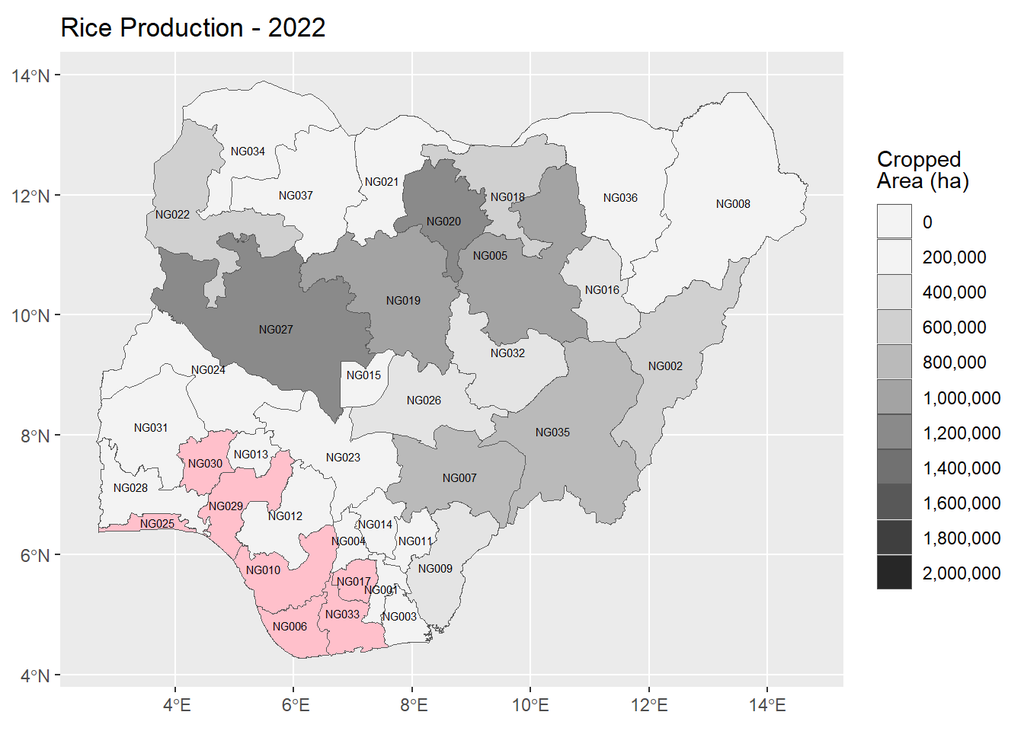

```r
ggplot(vect_rice_2022) +
  geom_spatvector(aes(fill = h_area_22_23_T)) +
  geom_spatvector_text(aes(label = adm1_pcode), size = 2) +
  scale_fill_stepsn(
      n.breaks = 10,
      limits = c(0, 2000000),
      colours = hcl.colors(palette = "Grays", 10, rev = T),
      guide = "legend",  na.value = "pink", labels = scales::comma
    ) +
  labs(
    title = "Rice Production - 2022",
    fill = "Cropped<br>Area (ha)") +
  theme(
    plot.title = element_markdown(),
    legend.title = element_markdown(),
    axis.title = element_blank()
  )
```

### Rice (MapSpam 2020)

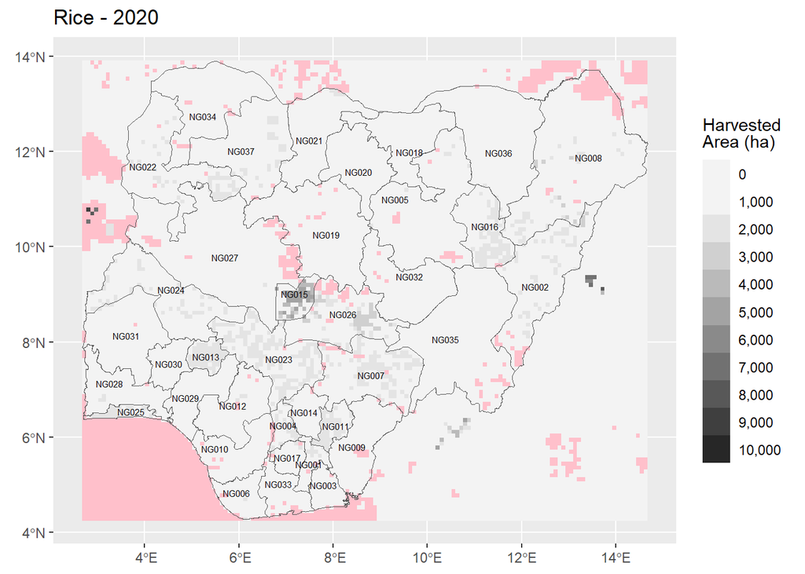

```r
ggplot() +
  geom_spatraster(data = rast_rice_spam_2020_nig) +
  geom_spatvector(data = vect_state_geo, fill = NA) +
  geom_spatvector_text(data = vect_state_geo, aes(label = adm1_pcode), size = 2) +
  scale_fill_stepsn(
      n.breaks = 10,
      limits = c(0, 10000),
      colours = hcl.colors(palette = "Grays", 10, rev = T),
      guide = "legend",  na.value = "pink", labels = scales::comma
    ) +
  labs(
    title = "Rice - 2020",
    fill = "Harvested<br>Area (ha)") +
  theme(
    plot.title = element_markdown(),
    legend.title = element_markdown(),
    axis.title = element_blank()
  )
```

### Compare sources for Rice

The table below displays all four sources together. The data are initially sorted according to the NAERLS data source, and by default the table shows the top 15 states - but you can change the number displayed. You can also change which column to sort by clicking on the arrows, and search for a specific state.

```r
df_rice_comb <- dplyr::left_join(
  dplyr::select(
    df_rice_2024,
    adm1_pcode,
    adm1_ref_name,
    rice_2024
  ),
  dplyr::select(df_rice_2023, adm1_pcode, rice_2023),
  by = 'adm1_pcode'
) |>
  dplyr::left_join(
    dplyr::select(df_rice_2022, rice_2022, adm1_ref_name),
    by = 'adm1_ref_name'
  ) |>
  dplyr::left_join(
    df_spam_rice_2,
    by = c('adm1_ref_name' = 'ADM1_NAME')
  )


df_rice_comb_rename <- df_rice_comb |> dplyr::rename(NAERLS_2024 = rice_2024, HarvestStat_2023 = rice_2023, NASS_2022 = rice_2022, MapSpam_2020 = sum_rice)

df_rice_comb_rename_round <- df_rice_comb_rename

df_rice_comb_rename_round$NAERLS_2024 <- round(df_rice_comb_rename$NAERLS_2024, digits = 0)
df_rice_comb_rename_round$HarvestStat_2023 <- round(df_rice_comb_rename$HarvestStat_2023, digits = 0)
df_rice_comb_rename_round$NASS_2022 <- round(df_rice_comb_rename$NASS_2022, digits = 0)
df_rice_comb_rename_round$MapSpam_2020 <- round(df_rice_comb_rename$MapSpam_2020, digits = 0)

df_rice_comb_rename_round |>
  base::sort_by(df_rice_comb_rename_round$NAERLS_2024, decreasing = T) |>
  DT::datatable(
    rownames = F,
    filter = "bottom",
    selection = list(mode = "none"),
    editable = FALSE,
    options = list(
      digits = 0,
      scrollX = TRUE,
      scrollCollapse = TRUE,
      autoWidth = TRUE,
      fixedColumns = list(leftColumns = 2),
      lengthMenu = c(15, 40),
      pageLength = 15
    )
  )
```

| adm1_pcode | adm1_ref_name | NAERLS_2024 | HarvestStat_2023 | NASS_2022 | MapSpam_2020 |
| --- | --- | --- | --- | --- | --- |
| NG023 | Kogi | 292468 | 288287 | 139690 | 276160 |
| NG027 | Niger | 281902 | 278285 | 1011942 | 264240 |
| NG007 | Benue | 275229 | 271295 | 679544 | 278982 |
| NG022 | Kebbi | 237565 | 234170 | 576951 | 221514 |
| NG024 | Kwara | 221392 | 218228 | 92970 | 205069 |
| NG035 | Taraba | 214929 | 211857 | 665672 | 204820 |
| NG015 | Federal Capital Territory | 210657 | 207646 | 42720 | 203749 |
| NG026 | Nasarawa | 197083 | 194266 | 232924 | 183734 |
| NG002 | Adamawa | 186228 | 183566 | 592646 | 169338 |
| NG016 | Gombe | 182543 | 179934 | 265055 | 137982 |

[output cut: 27 more lines]

For rice harvested area there is a strong alignment among between NAERLS and MapSpam, with Kogi, Niger and Benue states consistently high. However, there are obvious anomalies between NASS and the other sources, and a noticeably different pattern. The overall harvest areas are far higher for NASS than NAERLS, for instance, with Kano state estimated to have a harvest areas of over 1 million hectares. Kano was not a traditional rice producing state but has recently been gaining in recognition and has received investment in production and processing.

However, given the more recent data from NAERLS we will use this source for rice.

## Sorghum

### Sorghum (NAERLS/FMAFS 2024)

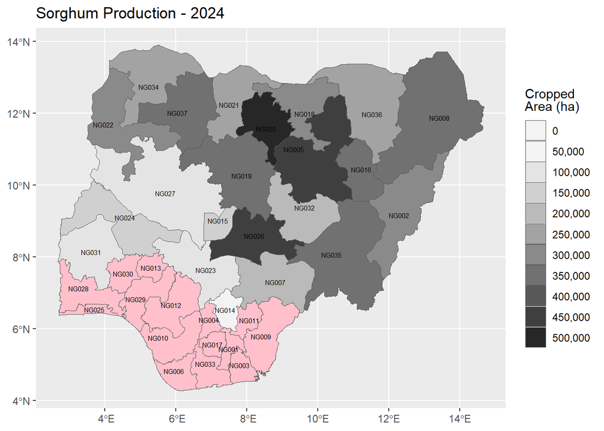

```r
ggplot(vect_sorghum_2024) +
  geom_spatvector(aes(fill = Area_Ha_2024)) +
  geom_spatvector_text(aes(label = adm1_pcode), size = 2) +
  scale_fill_stepsn(
      n.breaks = 10,
      limits = c(0, 500000),
      colours = hcl.colors(palette = "Grays", 10, rev = T),
      guide = "legend",  na.value = "pink", labels = scales::comma
    ) +
  labs(
    title = "Sorghum Production - 2024",
    fill = "Cropped<br>Area (ha)") +
  theme(
    plot.title = element_markdown(),
    legend.title = element_markdown(),
    axis.title = element_blank()
  )
```

### Sorghum (HarvestStat 2023)

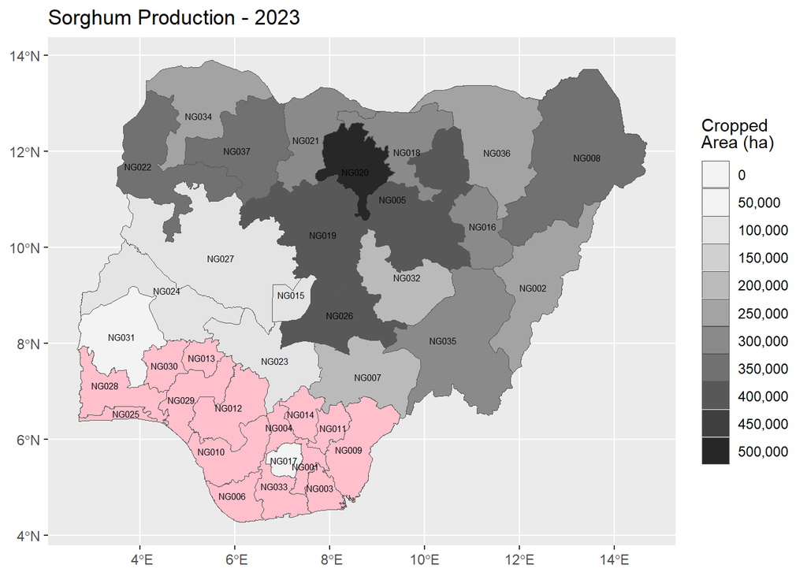

```r
ggplot(vect_sorghum_2023) +
  geom_spatvector(aes(fill = value)) +
  geom_spatvector_text(aes(label = adm1_pcode), size = 2) +
  scale_fill_stepsn(
      n.breaks = 10,
      limits = c(0, 500000),
      colours = hcl.colors(palette = "Grays", 10, rev = T),
      guide = "legend",  na.value = "pink", labels = scales::comma
    ) +
  labs(
    title = "Sorghum Production - 2023",
    fill = "Cropped<br>Area (ha)") +
  theme(
    plot.title = element_markdown(),
    legend.title = element_markdown(),
    axis.title = element_blank()
  )
```